# 라이온즈는 어떻게 다시 강팀이 되었나

[figure not shown]

## 0. 시작하기 전에

- 본 분석보고서는 **2021년 5월 3일을 기준으로 수집된 데이터를 기반으로 작성**되었습니다. 따라서 현재 순위와 선수들의 기록 간에는 차이가 있을 수 있습니다.
- 본 분석보고서에서 사용한 데이터셋은 제가 직접 개발한 [스탯티즈 크롤러](https://github.com/YeriNbow/KBO-Analysis/blob/main/Statiz%20Cralwer/statiz.py)를 이용하여 수집했습니다. 스탯티즈 크롤러는 야구 기록 사이트인 [스탯티즈](http://www.statiz.co.kr/stat.php)와 [KBO 공식 홈페이지](https://www.koreabaseball.com)에서 제공하는 선수 및 팀 기록에 대한 데이터를 크롤링하기 위해 제작되었습니다.
- 본 분석보고서의 제목인 **'라이온즈는 어떻게 다시 강팀이 되었나'** 는 2013년에 올라온 ['타이거즈는 어떻게 다시 강팀이 되었나'](https://sports.news.naver.com/news.nhn?oid=295&aid=0000000975) 라는 칼럼의 제목을 패러디 한 것 입니다. 공교롭게도 당시 시즌 초반 상승세를 타던 기아 타이거즈는 칼럼이 올라온 이후부터 급격하게 추락하여 8위로 시즌을 마감하였고 그해 우승은 삼성 라이온즈가 차지했습니다. 이후 이 칼럼은 야구팬들 사이에서 설레발의 대명사로 남아 아직까지도 회자되고 있습니다.
- 본 분석보고서는 야구 용어와 **세이버메트릭스(Sabermetrics)** 에 대한 배경지식을 어느정도 필요로 하나, 야구에 익숙하지 않다는 가정하에 쉽게 읽을 수 있도록 최대한 자세하게 작성하였습니다. 또한 과도한 세이버메트릭스 위주의 분석은 접근성을 떨어뜨리기 때문에, 여러 세이버메트릭스 지표들 중에서 필요한 것들만 최소한으로 선정하여 작성했습니다.
- 세이버메트릭스는 고전적인 야구 기록에 통계학적인 방법론을 도입하여 만들어지는 세부지표로, 이를 분석하고 연구하는 사람들을 세이버메트리션이라고 부릅니다. 세이버메트릭스는 미국 프로야구(MLB) 팀 중 하나인 Oakland Athletics가 세이버메트릭스를 기반으로 저평가된 선수들을 발굴하여 좋은 성적을 거둔 이후로 야구계에서 널리 퍼지게 되었습니다. 이러한 Oakland Athletics의 성공은 이후 'Moneyball' 이라는 영화로도 만들어졌으며, 최근 트랙맨 등의 첨단장비가 보편화되면서 KBO에서도 많은 팀들이 소위 '데이터 야구'를 외치며 세이버메트릭스를 통한 전력분석에 힘을 쏟고 있습니다.

## 1. 데이터셋 소개

분석에 사용되는 데이터셋은 스탯티즈 크롤러를 이용해 2010년부터 올해 5월 3일까지 최근 약 **10년간의 KBO 타자들의 기록**을 크롤링해 엑셀파일(.xlsx)로 저장한 데이터셋입니다. 각 데이터셋은 각 선수들의 안타나 홈런, 타율 같은 기본적인 야구 기록 외에도, 스탯티즈 사이트에서 제공하는 WAR, WRC+ 등의 세이버메트릭스 지표도 일부 포함하고 있습니다.

- 수집한 데이터셋은 [여기](https://github.com/YeriNbow/KBO-Analysis/blob/main/Dataset/kbo_batter_1021.xlsx)에서 확인할 수 있습니다.

#### - 타자 데이터셋 (kbo_batter_1021.xlsx) 변수표

| 변수명 | 설명 | 비고 |
| --- | --- | --- |
| Name | 선수이름 |  |
| Season | 년도 |  |
| Birth | 생년월일 |  |
| Team | 소속 팀 | 삼 : 삼성, 롯 : 롯데, 한 : 한화, 두 : 두산, 케 : KT, L : LG, K : 기아, S : SSG (구 SK), N : NC, 키 : 키움, 넥 : 넥센 |
| Position | 포지션 | 1B : 1루수, 2B : 2루수, 3B : 3루수, SS : 유격수, C : 포수, LF: 좌익수, RF : 우익수, CF : 중견수, DH : 지명타자, P : 투수 |
| WAR | 대체선수 대비 승리기여도 | 세이버메트릭스 지표 |
| G | 출장 경기 수 |  |
| PA | 타석 |  |
| AB | 타수 |  |
| R | 득점 |  |
| H | 안타 |  |
| 2B | 2루타 |  |
| 3B | 3루타 |  |
| HR | 홈런 |  |
| TB | 총루타 | 안타 + 2루타 x 2 + 3루타 x 3 + 홈런 x 4 |
| RBI | 타점 |  |
| SB | 도루 |  |
| CB | 도루실패 |  |
| BB | 볼넷 |  |
| HBP | 사구 |  |
| IBB | 고의사구 |  |
| SO | 삼진 |  |
| DP | 병살타 |  |
| SH | 희생번트 |  |
| SF | 희생플라이 |  |
| AVG | 타율 | 안타 / 타수 |
| OBP | 출루율 | (안타+볼넷+사구) / (타수+볼넷+사구+희생플라이) |
| SLG | 장타율 | 총루타 / 타수 |
| OPS | OPS | 출루율 + 장타율 |
| wOBA | 가중 출루율 | 세이버메트릭스 지표 |
| WRC+ | 조정 WRC | 세이버메트릭스 지표 |

#### - 데이터셋 내의 주요 지표에 대한 설명

1. WAR (Wins Above Replacement, 대체선수 대비 승리기여도)

   ```
   WAR은 세이버메트릭스 지표들 중 가장 쉽게 접근할 수 있는 지표 중 하나로, 어떤 선수가 대체선수에 비해 팀 '승리'에 얼마나 기여했는지를 나타내는 지표입니다. 이 지표의 기준인 '대체선수'는 1군 선수가 이탈된 상황에서 빈자리를 채우기 위해 어쩔 수 없이 쓸 수 밖에 없는 선수를 의미하며, 일반적으로 2군 선수 중 1군으로 가끔씩 콜업되는 비상 선발 선수라고 할 수 있습니다. WAR의 계산 방식은 세이버메트리션마다 조금씩 다르나, 본 데이터셋에서는 스탯티즈의 WAR 계산방식을 따릅니다. 보통 WAR의 값이 0 이하면 대체선수, 0 ~ 2 사이면 후보선수, 2 ~ 6 사이면 주전선수로 분류되며 6 이상의 WAR을 가진 선수는 리그 정상급의 선수로 볼 수 있습니다.
   ```

2. AVG (Average, 타율), OBP (On Base Percentage, 출루율), SLG (Slugging, 장타율)

   ```
   타율, 출루율, 장타율은 타자의 타격능력을 평가하기 위한 가장 고전적인 기록입니다. 타율과 출루율은 0 ~ 1 사이의 값을 가지고, 장타율은 0 ~ 4 까지의 값을 가질 수 있습니다. 일반적으로 타율 3할, 출루율 4할, 장타율 5할을 갖춘 선수가 이상적이며, 팀에서 중심 타선을 이끌 만한 생산성을 가진 선수로 판단할 수 있습니다.
   ```

3. OPS (On-base Plus Slugging)

   ```
   OPS는 출루율 + 장타율로 계산되는 매우 단순한 지표이나 타자의 득점 생산성을 판단하기 가장 좋은 지표 중 하나입니다. 0 ~ 5 사이의 값을 가지며, 평균적으로 선수들은 0.8 정도의 OPS를 가집니다. OPS가 1 이상일 경우 리그 정상급의 타자로 판단할 수 있습니다.
   ```

4. wOBA (weighted On Base Average)

   ```
   wOBA는 타석에서의 타자의 순수한 타격 생산능력만을 평가하기 위해 고안된 지표로 계산과정에서 부가적인 수비 요소나 주루의 영향 등은 전혀 고려하지 않습니다. 0.32 정도가 평균적인 타자로 분류되고 0.4 이상이면 생산성이 좋은 타자, 0.3 이하면 생산성이 낮은 타자로 판단할 수 있습니다.
   ```

5. WRC+ (Weighted Runs Created+, 조정 득점 생산력)

   ```
   득점생산력을 나타내는 WRC에 '파크팩터'(구장의 성향을 나타내는 지표 : 1보다 크면 타자 친화, 1보다 작으면 투수 친화 구장을 의미)를 반영하여 조정된 WRC를 의미합니다. wOBA에서 확장된 지표로 타자의 득점 생산력을 나타내는 가장 효과적인 세이버메트릭스 지표입니다. 리그 평균을 100으로 두고 타자의 생산성을 비교할 수 있습니다.
   ```

## 2. 데이터 준비 및 이해

분석 시작 전, 데이터셋의 대략적인 구조를 파악하고, 분석과정에서의 파일 변경을 대비하기 위해 백업파일을 생성합니다.

#### - 주요 libary import

```python
import pandas as pd
import numpy as np
import matplotlib.pyplot as plt
import seaborn as sns
import scipy as sp

from matplotlib import font_manager, rc
font_name = font_manager.FontProperties(fname="c:/Windows/Fonts/malgun.ttf").get_name()
rc('font', family=font_name)
plt.rc('axes', unicode_minus=False)
plt.rcParams['figure.figsize'] = (15, 7)

file_path = r'D:\IT\mywork\Project\KBO-Analysis\Dataset\{0}'
```

#### - 타자 데이터 가져오기

```python
batter_df = pd.read_excel(file_path.format('kbo_batter_1021.xlsx'), encoding='utf-8', index=False)
batter_df
```

|  | Name | Season | Birth | Team | Position | WAR | G | PA | AB | R | ... | SO | DP | SH | SF | AVG | OBP | SLG | OPS | wOBA | WRC+ |
| --- | --- | --- | --- | --- | --- | --- | --- | --- | --- | --- | --- | --- | --- | --- | --- | --- | --- | --- | --- | --- | --- |
| 0 | 이대호 | 10.0 | 1982-06-21 | 롯 | 3B | 8.82 | 127 | 552 | 478 | 99 | ... | 77 | 15 | 0 | 3 | 0.364 | 0.444 | 0.667 | 1.111 | 0.482 | 192.4 |
| 1 | 조인성 | 10.0 | 1975-05-25 | L | C | 5.96 | 133 | 511 | 457 | 69 | ... | 83 | 19 | 5 | 5 | 0.317 | 0.374 | 0.558 | 0.932 | 0.401 | 140.0 |
| 2 | 김현수 | 10.0 | 1988-01-12 | 두 | LF | 5.24 | 132 | 565 | 473 | 88 | ... | 64 | 9 | 0 | 8 | 0.317 | 0.414 | 0.531 | 0.945 | 0.419 | 152.0 |
| 3 | 홍성흔 | 10.0 | 1977-02-28 | 롯 | DH | 5.15 | 111 | 498 | 431 | 88 | ... | 49 | 18 | 1 | 5 | 0.350 | 0.427 | 0.601 | 1.028 | 0.451 | 171.9 |
| 4 | 최정 | 10.0 | 1987-02-28 | S | 3B | 5.07 | 123 | 493 | 400 | 84 | ... | 72 | 7 | 16 | 8 | 0.300 | 0.396 | 0.533 | 0.929 | 0.400 | 138.8 |
| ... | ... | ... | ... | ... | ... | ... | ... | ... | ... | ... | ... | ... | ... | ... | ... | ... | ... | ... | ... | ... | ... |
| 3768 | 김창평 | 21.0 | 2000-06-14 | S | 3B | -0.33 | 15 | 13 | 12 | 3 | ... | 3 | 0 | 1 | 0 | 0.000 | 0.000 | 0.000 | 0.000 | 0.000 | -129.1 |
| 3769 | 도태훈 | 21.0 | 1993-03-18 | N | 3B | -0.37 | 11 | 24 | 22 | 4 | ... | 4 | 1 | 0 | 0 | 0.045 | 0.125 | 0.045 | 0.171 | 0.104 | -61.1 |
| 3770 | 이성열 | 21.0 | 1984-07-13 | 한 | DH | -0.39 | 16 | 46 | 38 | 6 | ... | 10 | 0 | 0 | 1 | 0.158 | 0.283 | 0.158 | 0.441 | 0.240 | 29.0 |
| 3771 | 임종찬 | 21.0 | 2001-09-28 | 한 | RF | -0.40 | 19 | 68 | 61 | 4 | ... | 24 | 1 | 0 | 0 | 0.148 | 0.235 | 0.246 | 0.481 | 0.237 | 25.7 |
| 3772 | 김동엽 | 21.0 | 1990-07-24 | 삼 | DH | -0.45 | 11 | 39 | 32 | 3 | ... | 10 | 1 | 0 | 3 | 0.125 | 0.205 | 0.125 | 0.330 | 0.176 | -12.2 |

3773 rows × 31 columns

#### - 원본 데이터 저장하기 (백업)

원본 데이터 변경 방지를 위해 데이터셋을 백업합니다.

```python
batter_df.to_excel(file_path.format('batter_1021')+'_backup.xlsx', encoding='utf-8', index=False)
```

#### - 백업 파일 확인

```python
batter_backup = pd.read_excel(file_path.format('batter_1021_backup.xlsx'), encoding='utf-8', index=False)

batter_backup.head()
```

|  | Name | Season | Birth | Team | Position | WAR | G | PA | AB | R | ... | SO | DP | SH | SF | AVG | OBP | SLG | OPS | wOBA | WRC+ |
| --- | --- | --- | --- | --- | --- | --- | --- | --- | --- | --- | --- | --- | --- | --- | --- | --- | --- | --- | --- | --- | --- |
| 0 | 이대호 | 10.0 | 1982-06-21 | 롯 | 3B | 8.82 | 127 | 552 | 478 | 99 | ... | 77 | 15 | 0 | 3 | 0.364 | 0.444 | 0.667 | 1.111 | 0.482 | 192.4 |
| 1 | 조인성 | 10.0 | 1975-05-25 | L | C | 5.96 | 133 | 511 | 457 | 69 | ... | 83 | 19 | 5 | 5 | 0.317 | 0.374 | 0.558 | 0.932 | 0.401 | 140.0 |
| 2 | 김현수 | 10.0 | 1988-01-12 | 두 | LF | 5.24 | 132 | 565 | 473 | 88 | ... | 64 | 9 | 0 | 8 | 0.317 | 0.414 | 0.531 | 0.945 | 0.419 | 152.0 |
| 3 | 홍성흔 | 10.0 | 1977-02-28 | 롯 | DH | 5.15 | 111 | 498 | 431 | 88 | ... | 49 | 18 | 1 | 5 | 0.350 | 0.427 | 0.601 | 1.028 | 0.451 | 171.9 |
| 4 | 최정 | 10.0 | 1987-02-28 | S | 3B | 5.07 | 123 | 493 | 400 | 84 | ... | 72 | 7 | 16 | 8 | 0.300 | 0.396 | 0.533 | 0.929 | 0.400 | 138.8 |

5 rows × 31 columns

#### - 타자 데이터셋의 전체적인 구조 파악

본격적인 분석에 앞서 데이터셋의 전체적인 구조를 파악합니다.

```python
batter_df
```

|  | Name | Season | Birth | Team | Position | WAR | G | PA | AB | R | ... | SO | DP | SH | SF | AVG | OBP | SLG | OPS | wOBA | WRC+ |
| --- | --- | --- | --- | --- | --- | --- | --- | --- | --- | --- | --- | --- | --- | --- | --- | --- | --- | --- | --- | --- | --- |
| 0 | 이대호 | 10.0 | 1982-06-21 | 롯 | 3B | 8.82 | 127 | 552 | 478 | 99 | ... | 77 | 15 | 0 | 3 | 0.364 | 0.444 | 0.667 | 1.111 | 0.482 | 192.4 |
| 1 | 조인성 | 10.0 | 1975-05-25 | L | C | 5.96 | 133 | 511 | 457 | 69 | ... | 83 | 19 | 5 | 5 | 0.317 | 0.374 | 0.558 | 0.932 | 0.401 | 140.0 |
| 2 | 김현수 | 10.0 | 1988-01-12 | 두 | LF | 5.24 | 132 | 565 | 473 | 88 | ... | 64 | 9 | 0 | 8 | 0.317 | 0.414 | 0.531 | 0.945 | 0.419 | 152.0 |
| 3 | 홍성흔 | 10.0 | 1977-02-28 | 롯 | DH | 5.15 | 111 | 498 | 431 | 88 | ... | 49 | 18 | 1 | 5 | 0.350 | 0.427 | 0.601 | 1.028 | 0.451 | 171.9 |
| 4 | 최정 | 10.0 | 1987-02-28 | S | 3B | 5.07 | 123 | 493 | 400 | 84 | ... | 72 | 7 | 16 | 8 | 0.300 | 0.396 | 0.533 | 0.929 | 0.400 | 138.8 |
| ... | ... | ... | ... | ... | ... | ... | ... | ... | ... | ... | ... | ... | ... | ... | ... | ... | ... | ... | ... | ... | ... |
| 3768 | 김창평 | 21.0 | 2000-06-14 | S | 3B | -0.33 | 15 | 13 | 12 | 3 | ... | 3 | 0 | 1 | 0 | 0.000 | 0.000 | 0.000 | 0.000 | 0.000 | -129.1 |
| 3769 | 도태훈 | 21.0 | 1993-03-18 | N | 3B | -0.37 | 11 | 24 | 22 | 4 | ... | 4 | 1 | 0 | 0 | 0.045 | 0.125 | 0.045 | 0.171 | 0.104 | -61.1 |
| 3770 | 이성열 | 21.0 | 1984-07-13 | 한 | DH | -0.39 | 16 | 46 | 38 | 6 | ... | 10 | 0 | 0 | 1 | 0.158 | 0.283 | 0.158 | 0.441 | 0.240 | 29.0 |
| 3771 | 임종찬 | 21.0 | 2001-09-28 | 한 | RF | -0.40 | 19 | 68 | 61 | 4 | ... | 24 | 1 | 0 | 0 | 0.148 | 0.235 | 0.246 | 0.481 | 0.237 | 25.7 |
| 3772 | 김동엽 | 21.0 | 1990-07-24 | 삼 | DH | -0.45 | 11 | 39 | 32 | 3 | ... | 10 | 1 | 0 | 3 | 0.125 | 0.205 | 0.125 | 0.330 | 0.176 | -12.2 |

3773 rows × 31 columns

```python
batter_df.info()
```

```
<class 'pandas.core.frame.DataFrame'>
RangeIndex: 3773 entries, 0 to 3772
Data columns (total 31 columns):
 #   Column    Non-Null Count  Dtype
---  ------    --------------  -----
 0   Name      3043 non-null   object
 1   Season    3043 non-null   float64
 2   Birth     3773 non-null   object
 3   Team      3773 non-null   object
 4   Position  3612 non-null   object
 5   WAR       3773 non-null   float64
 6   G         3773 non-null   int64
 7   PA        3773 non-null   int64
 8   AB        3773 non-null   int64
 9   R         3773 non-null   int64
```

[output cut: 23 more lines]

타자 데이터셋은 총 3773개의 행과 31개의 열로 이루어진 데이터셋입니다. Name, Team, Postion, Season변수는 범주형 변수로 구분될 수 있고 Birth 변수의 경우는 시계열 변수로 볼 수 있습니다. 다만 Birth 변수와 Season 변수의 자료형이 올바른 형식이 아니기 때문에 추가적인 작업이 필요해 보입니다. 그리고 이들을 제외한 나머지 26개의 변수는 모두 수치형 변수로 구분할 수 있습니다. 또한 각 변수들은 전체 3773개의 행을 가져야하지만 Name, Season, Position, AVG, OBP, SLG, OPS, wOBA, WRC+ 변수는 결측치를 포함하고 있어 해당 변수들은 이후 전처리 작업이 필요할 것으로 보입니다.

## 3. 데이터 클린징

### 3.1 결측치 처리

#### - 결측치 확인

어떤 변수가 결측치를 포함하고 있는지 확인하고, 결측치를 포함하는 행을 찾아 대응방법을 결정합니다.

```python
batter_df = batter_backup.copy()
batter_df.isnull().sum()
```

```
Name        730
Season      730
Birth         0
Team          0
Position    161
WAR           0
G             0
PA            0
AB            0
R             0
H             0
2B            0
3B            0
HR            0
TB            0
RBI           0
SB            0
CB            0
BB            0
HBP           0
IBB           0
SO            0
DP            0
SH            0
SF            0
AVG         746
OBP         740
SLG         746
OPS         746
wOBA        740
WRC+        812
dtype: int64
```

```python
missing = batter_df[batter_df.Name.isnull() | batter_df.Season.isnull() | batter_df.Position.isnull() | batter_df.AVG.isnull()
                    | batter_df.OBP.isnull() | batter_df.SLG.isnull() | batter_df.OPS.isnull() | batter_df.wOBA.isnull()
                    | batter_df['WRC+'].isnull()]

missing
```

|  | Name | Season | Birth | Team | Position | WAR | G | PA | AB | R | ... | SO | DP | SH | SF | AVG | OBP | SLG | OPS | wOBA | WRC+ |
| --- | --- | --- | --- | --- | --- | --- | --- | --- | --- | --- | --- | --- | --- | --- | --- | --- | --- | --- | --- | --- | --- |
| 109 | 윤요섭 | 10.0 | 1982-03-30 | SL | NaN | 0.10 | 46 | 57 | 51 | 4 | ... | 16 | 0 | 1 | 1 | 0.294 | 0.339 | 0.294 | 0.633 | 0.301 | 72.4 |
| 119 | 장종덕 | 10.0 | 1987-10-29 | 넥 | NaN | 0.02 | 2 | 3 | 3 | 0 | ... | 3 | 0 | 0 | 0 | 0.000 | 0.000 | 0.000 | 0.000 | 0.000 | NaN |
| 120 | 최경철 | 10.0 | 1980-08-15 | S | C | 0.01 | 1 | 2 | 2 | 0 | ... | 2 | 0 | 0 | 0 | 0.000 | 0.000 | 0.000 | 0.000 | 0.000 | NaN |
| 122 | 변용선 | 10.0 | 1987-05-17 | 롯 | NaN | 0.01 | 3 | 3 | 3 | 1 | ... | 1 | 0 | 0 | 0 | 0.333 | 0.333 | 0.333 | 0.667 | 0.315 | 82.0 |
| 123 | 김성현 | 10.0 | 1989-01-03 | 넥 | P | 0.01 | 1 | 1 | 1 | 0 | ... | 1 | 0 | 0 | 0 | 0.000 | 0.000 | 0.000 | 0.000 | 0.000 | NaN |
| ... | ... | ... | ... | ... | ... | ... | ... | ... | ... | ... | ... | ... | ... | ... | ... | ... | ... | ... | ... | ... | ... |
| 3701 | NaN | NaN | 1992-07-24 | 김민수21K | P | 0.00 | 1 | 0 | 0 | 0 | ... | 0 | 0 | 0 | 0 | NaN | NaN | NaN | NaN | NaN | NaN |
| 3707 | 장준원 | 21.0 | 1995-11-21 | L | NaN | -0.02 | 1 | 1 | 1 | 0 | ... | 0 | 0 | 0 | 0 | 0.000 | 0.000 | 0.000 | 0.000 | 0.000 | -129.1 |
| 3714 | 이정훈 | 21.0 | 1994-12-07 | K | NaN | -0.05 | 2 | 2 | 2 | 0 | ... | 0 | 0 | 0 | 0 | 0.000 | 0.000 | 0.000 | 0.000 | 0.000 | -129.1 |
| 3716 | 김민혁 | 21.0 | 1996-05-03 | 두 | NaN | -0.05 | 2 | 2 | 2 | 0 | ... | 1 | 0 | 0 | 0 | 0.000 | 0.000 | 0.000 | 0.000 | 0.000 | -129.1 |
| 3717 | 신성현 | 21.0 | 1990-10-19 | 두 | NaN | -0.05 | 1 | 2 | 2 | 0 | ... | 0 | 0 | 0 | 0 | 0.000 | 0.000 | 0.000 | 0.000 | 0.000 | -129.1 |

939 rows × 31 columns

```python
print('결측치 행 중 43경기 이상 출전 선수 :', missing[missing.G>43].Name.unique())
missing[missing.G>43]
```

```
결측치 행 중 43경기 이상 출전 선수 : ['윤요섭' '조재호' '박준서' '신종길' '서상우' '전민수']
```

|  | Name | Season | Birth | Team | Position | WAR | G | PA | AB | R | ... | SO | DP | SH | SF | AVG | OBP | SLG | OPS | wOBA | WRC+ |
| --- | --- | --- | --- | --- | --- | --- | --- | --- | --- | --- | --- | --- | --- | --- | --- | --- | --- | --- | --- | --- | --- |
| 109 | 윤요섭 | 10.0 | 1982-03-30 | SL | NaN | 0.10 | 46 | 57 | 51 | 4 | ... | 16 | 0 | 1 | 1 | 0.294 | 0.339 | 0.294 | 0.633 | 0.301 | 72.4 |
| 252 | 조재호 | 10.0 | 1980-01-10 | 넥 | NaN | -0.34 | 46 | 36 | 33 | 6 | ... | 9 | 0 | 0 | 0 | 0.121 | 0.194 | 0.121 | 0.316 | 0.167 | -17.8 |
| 353 | 윤요섭 | 11.0 | 1982-03-30 | L | NaN | 0.54 | 67 | 91 | 77 | 8 | ... | 22 | 4 | 0 | 1 | 0.221 | 0.330 | 0.455 | 0.784 | 0.353 | 112.4 |
| 1202 | 박준서 | 14.0 | 1981-12-11 | 롯 | NaN | 0.04 | 74 | 118 | 99 | 9 | ... | 24 | 1 | 1 | 3 | 0.232 | 0.325 | 0.343 | 0.668 | 0.304 | 64.3 |
| 2432 | 신종길 | 17.0 | 1983-12-31 | K | NaN | -0.12 | 64 | 90 | 83 | 13 | ... | 13 | 1 | 0 | 2 | 0.241 | 0.278 | 0.361 | 0.639 | 0.283 | 56.8 |
| 2605 | 서상우 | 18.0 | 1989-09-17 | L | NaN | 0.32 | 51 | 84 | 69 | 10 | ... | 18 | 1 | 0 | 2 | 0.290 | 0.393 | 0.377 | 0.770 | 0.354 | 106.5 |
| 2965 | 전민수 | 19.0 | 1989-03-18 | L | NaN | 0.06 | 75 | 106 | 96 | 8 | ... | 18 | 4 | 1 | 0 | 0.240 | 0.305 | 0.313 | 0.617 | 0.291 | 72.4 |

7 rows × 31 columns

결측치가 존재하는 939개의 데이터들 중에서, 전체 경기(현 144경기 기준)의 30%인 43경기 이상을 출전한 선수는 '윤요섭', '조재호', '박준서', '신종길', '서상우', '전민수' 단 6명인 것으로 확인됩니다. 추가적으로 이 6명의 선수의 데이터를 확인해본 결과, 이들은 모두 주전 선수 급으로 출전하지는 않았지만 주로 대타/대수비 요원으로써 팀에 기여한 것으로 보여집니다. **따라서 이들을 제외한 나머지 선수들은 전체 경기의 30%도 완전히 출전하지 못하는 대체선수 수준의 선수들이기 때문에 경기 기록이 완전하지 않아 결측치가 존재하는 것으로 파악됩니다.**

#### - 결측치 대체를 위한 선수들의 Position 확인

앞서 확인한 6명의 선수들은 다음과 같이 전부 Position 변수에 결측치를 가지고 있습니다. 이 6명의 선수는 경기 기록상 모두 대타/대수비 요원으로 활약하면서, 한 시즌에 30% 이상 출전했기 때문에 팀 전력에 어느정도 영향을 주었다고 판단할 수 있습니다. 따라서 해당 선수들은 결측치를 포함하고 있다고 하여 무작정 제거하기 보다는, 각 선수들이 활약한 다른 년도에서 이 선수들의 주 포지션을 찾아 결측치를 대체하는 것이 좋습니다.

```python
print('결측치 대체 전 윤요섭 position : ', batter_df[(batter_df.Name == '윤요섭')].Position.unique())
print('결측치 대체 전 조재호 position : ', batter_df[(batter_df.Name == '조재호')].Position.unique())
print('결측치 대체 전 박준서 position : ', batter_df[(batter_df.Name == '박준서')].Position.unique())
print('결측치 대체 전 신종길 position : ', batter_df[(batter_df.Name == '신종길')].Position.unique())
print('결측치 대체 전 서상우 position : ', batter_df[(batter_df.Name == '서상우')].Position.unique())
print('결측치 대체 전 전민수 position : ', batter_df[(batter_df.Name == '전민수')].Position.unique())
```

```
결측치 대체 전 윤요섭 position :  [nan 'C' 'DH']
결측치 대체 전 조재호 position :  [nan 'RF' 'LF']
결측치 대체 전 박준서 position :  ['2B' 'SS' nan]
결측치 대체 전 신종길 position :  ['RF' nan]
결측치 대체 전 서상우 position :  ['1B' 'DH' nan]
결측치 대체 전 전민수 position :  ['RF' 'LF' nan]
```

#### - 결측치 대체

- 윤요섭 : C (포수)
- 조재호 : RF (우익수)
- 박준서 : 2B (2루수)
- 신종길 : RF (우익수)
- 서상우 : 1B (1루수)
- 전민수 : RF (우익수)

```python
batter_df[batter_df.Name == '윤요섭'] = batter_df[batter_df.Name == '윤요섭'].fillna('C')
batter_df[batter_df.Name == '박준서'] = batter_df[batter_df.Name == '박준서'].fillna('2B')
batter_df[batter_df.Name == '서상우'] = batter_df[batter_df.Name == '서상우'].fillna('1B')

batter_df[(batter_df.Name == '조재호') | (batter_df.Name == '신종길') | (batter_df.Name == '전민수')] = batter_df[
    (batter_df.Name == '조재호') | (batter_df.Name == '신종길') | (batter_df.Name == '전민수')].fillna('RF')
```

#### - 결측치 대체 확인

결측치 대체가 올바르게 수행되었는지 확인합니다. Position 변수의 NaN값이 모두 대체된 것을 확인할 수 있습니다.

```python
print('결측치 대체 후 윤요섭 position : ', batter_df[(batter_df.Name == '윤요섭')].Position.unique())
print('결측치 대체 후 조재호 position : ', batter_df[(batter_df.Name == '조재호')].Position.unique())
print('결측치 대체 후 박준서 position : ', batter_df[(batter_df.Name == '박준서')].Position.unique())
print('결측치 대체 후 신종길 position : ', batter_df[(batter_df.Name == '신종길')].Position.unique())
print('결측치 대체 후 서상우 position : ', batter_df[(batter_df.Name == '서상우')].Position.unique())
print('결측치 대체 후 전민수 position : ', batter_df[(batter_df.Name == '전민수')].Position.unique())
```

```
결측치 대체 후 윤요섭 position :  ['C' 'DH']
결측치 대체 후 조재호 position :  ['RF' 'LF']
결측치 대체 후 박준서 position :  ['2B' 'SS']
결측치 대체 후 신종길 position :  ['RF']
결측치 대체 후 서상우 position :  ['1B' 'DH']
결측치 대체 후 전민수 position :  ['RF' 'LF']
```

#### - 결측치 제거

앞서 결측치 대체를 진행한 6명의 선수를 제외한 결측치가 존재하는 나머지 선수들은, 전체의 30%인 43경기도 제대로 출전하지 못하는 대체선수 수준의 선수들 입니다. 앞서 언급했듯이, 대체선수는 팀이 비상상황에서 어쩔 수 없이 사용하는 선수로, 1군 후보선수들과 비교하여도 실력차이가 극심한 선수들을 의미합니다. 따라서 이 선수들의 결측치를 평균이나 중앙값으로 대체하는 것은 오히려 데이터를 왜곡할 위험이 크기 때문에 결측치 제거를 수행합니다.

```python
batter_df = batter_df.dropna(axis=0)
```

#### - 결측치 제거 확인

결측치 제거가 올바르게 수행되었는지 확인합니다. 모든 변수들의 NaN값이 제거된 것을 확인할 수 있습니다.

```python
batter_df.isnull().sum()
```

```
Name        0
Season      0
Birth       0
Team        0
Position    0
WAR         0
G           0
PA          0
AB          0
R           0
H           0
2B          0
3B          0
HR          0
TB          0
RBI         0
SB          0
CB          0
BB          0
HBP         0
IBB         0
SO          0
DP          0
SH          0
SF          0
AVG         0
OBP         0
SLG         0
OPS         0
wOBA        0
WRC+        0
dtype: int64
```

### 3.2 파생변수 생성과 변수 선택

앞선 과정을 통해 결측치는 제거되었지만 데이터셋에는 여전히 31개의 많은 변수가 저장되어 있습니다. 이상치 제거에 앞서, 이 31개의 모든 변수들을 분석하는 것은 효과적이지 못할 뿐 아니라, 일부 변수는 분석에 있어 그렇게 유의미한 정보를 제공하고 있지 않을 가능성도 존재합니다. 따라서 효과적인 분석을 위해 잘못 저장된 변수들을 올바른 형식으로 변환하고, 분석에 필요한 새로운 변수들을 추가하고 선택하는 과정이 필요합니다.

#### - index 재설정 및 Season, Birth 변수 변환

Season은 범주형 변수이고 Birth 변수는 시계열 변수입니다. 하지만 앞서 info( )를 통해 데이터셋의 전체적인 구조를 확인해본 결과, Season과 Birth가 각각 float와 odject형으로 저장되어있는 것을 확인할 수 있습니다. 특히 Season 변수의 경우 년도에서 2000이 생략된 10, 11 등의 형태로 저장되어 있기 때문에 2010, 2011 등으로 년도값을 올바르게 바꿔주어야 합니다. 따라서 다음과 같이 Season과 Birth 변수를 올바른 형식으로 형변환하고, 추가적으로 결측치가 제거된 데이터셋의 전체 index도 재설정합니다.

```python
batter_df.Season = batter_df.Season.apply(lambda x: int(x)+2000)
batter_df.Season = batter_df.Season.astype(object)
batter_df.Birth = pd.to_datetime(batter_df.Birth, format='%Y-%m-%d')
batter_df.reset_index(inplace=True, drop=True)
batter_df
```

|  | Name | Season | Birth | Team | Position | WAR | G | PA | AB | R | ... | SO | DP | SH | SF | AVG | OBP | SLG | OPS | wOBA | WRC+ |
| --- | --- | --- | --- | --- | --- | --- | --- | --- | --- | --- | --- | --- | --- | --- | --- | --- | --- | --- | --- | --- | --- |
| 0 | 이대호 | 2010 | 1982-06-21 | 롯 | 3B | 8.82 | 127 | 552 | 478 | 99 | ... | 77 | 15 | 0 | 3 | 0.364 | 0.444 | 0.667 | 1.111 | 0.482 | 192.4 |
| 1 | 조인성 | 2010 | 1975-05-25 | L | C | 5.96 | 133 | 511 | 457 | 69 | ... | 83 | 19 | 5 | 5 | 0.317 | 0.374 | 0.558 | 0.932 | 0.401 | 140.0 |
| 2 | 김현수 | 2010 | 1988-01-12 | 두 | LF | 5.24 | 132 | 565 | 473 | 88 | ... | 64 | 9 | 0 | 8 | 0.317 | 0.414 | 0.531 | 0.945 | 0.419 | 152.0 |
| 3 | 홍성흔 | 2010 | 1977-02-28 | 롯 | DH | 5.15 | 111 | 498 | 431 | 88 | ... | 49 | 18 | 1 | 5 | 0.350 | 0.427 | 0.601 | 1.028 | 0.451 | 171.9 |
| 4 | 최정 | 2010 | 1987-02-28 | S | 3B | 5.07 | 123 | 493 | 400 | 84 | ... | 72 | 7 | 16 | 8 | 0.300 | 0.396 | 0.533 | 0.929 | 0.400 | 138.8 |
| ... | ... | ... | ... | ... | ... | ... | ... | ... | ... | ... | ... | ... | ... | ... | ... | ... | ... | ... | ... | ... | ... |
| 2838 | 김창평 | 2021 | 2000-06-14 | S | 3B | -0.33 | 15 | 13 | 12 | 3 | ... | 3 | 0 | 1 | 0 | 0.000 | 0.000 | 0.000 | 0.000 | 0.000 | -129.1 |
| 2839 | 도태훈 | 2021 | 1993-03-18 | N | 3B | -0.37 | 11 | 24 | 22 | 4 | ... | 4 | 1 | 0 | 0 | 0.045 | 0.125 | 0.045 | 0.171 | 0.104 | -61.1 |
| 2840 | 이성열 | 2021 | 1984-07-13 | 한 | DH | -0.39 | 16 | 46 | 38 | 6 | ... | 10 | 0 | 0 | 1 | 0.158 | 0.283 | 0.158 | 0.441 | 0.240 | 29.0 |
| 2841 | 임종찬 | 2021 | 2001-09-28 | 한 | RF | -0.40 | 19 | 68 | 61 | 4 | ... | 24 | 1 | 0 | 0 | 0.148 | 0.235 | 0.246 | 0.481 | 0.237 | 25.7 |
| 2842 | 김동엽 | 2021 | 1990-07-24 | 삼 | DH | -0.45 | 11 | 39 | 32 | 3 | ... | 10 | 1 | 0 | 3 | 0.125 | 0.205 | 0.125 | 0.330 | 0.176 | -12.2 |

2843 rows × 31 columns

```python
batter_df.dtypes
```

```
Name                object
Season              object
Birth       datetime64[ns]
Team                object
Position            object
WAR                float64
G                    int64
PA                   int64
AB                   int64
R                    int64
H                    int64
2B                   int64
3B                   int64
HR                   int64
TB                   int64
RBI                  int64
SB                   int64
CB                   int64
BB                   int64
HBP                  int64
IBB                  int64
SO                   int64
DP                   int64
SH                   int64
SF                   int64
AVG                float64
OBP                float64
SLG                float64
OPS                float64
wOBA               float64
WRC+               float64
dtype: object
```

#### - 파생변수 BABIP, Age 생성

변수 선택에 앞서 분석에 사용할 새로운 파생변수 BABIP과 Age을 추가적으로 생성합니다. 변수들에 대한 설명은 다음과 같습니다.

   ```
    * BABIP (Batting Average on Balls In Play, 인플레이 타구의 타율)

    BABIP은 현대 세이버메트릭스 분석에 있어 가장 중요하면서도 인기있는 지표 중 하나입니다. BABIP에서 말하는 '인플레이 타구'는 투수가 던진 공이 타자에 의해 '페어지역 안으로 떨어지는 타구'를 의미합니다. 그렇기 때문에 계산식에서도 포수가 공을 잡거나(삼진), 페어지역 밖인 펜스를 넘어가는 경우(홈런)는 인플레이 타구에서 제외됩니다. 즉, BABIP은 타자가 공을 어떤 방식으로든 쳐서, 그 결과로 발생되는 모든 인플레이 타구가 실제 안타까지 이어질 확률을 나타내는 지표라고 할 수 있습니다.

    이런 BABIP이 현대야구에서 주목받는 이유는 '인플레이 상황'에서 만들어지는 지표라는 점에 있습니다. 타자가 만들어낸 타구가 페어지역에 떨어지면 그 타구에 어떻게 대응하는지에 따라 그 결과가 바뀔 수 있기 때문입니다. 실제 야구를 살펴보더라도 평범한 뜬공이 외야수의 실책에 의해 출루로 이어지거나, 좋은 안타성 타구가 예상치 못한 호수비에 의해 아웃으로 바뀌어 버리는 경우가 비일비재합니다. 즉, 평범한 실력의 선수라도 이러한 예상치 못한 변수들이 계속 좋은 쪽으로 이어진다면 그 타자는 높은 BABIP을 가지게 될 것이고, 반대로 평소에 잘하던 타자라도 좋은 타구들이 계속 호수비에 가로막힌다면 자연스럽게 BABIP은 낮아질 것입니다. 다시말해 BABIP은 일정 부분이 '운'에 의해 결정될 수 있는 특이한 지표라고 할 수 있습니다.

    이러한 점으로 인해 타자들의 BABIP은 매시즌마다 천차만별이지만, 장기적인 관점에서는 일정한 값으로 수렴한다고 알려져 있습니다. 하지만 무엇보다도 BABIP이라는 지표는 다양한 방식으로 해석이 가능하기 때문에 현대 야구 분석에 있어 중요한 위치를 차지하고 있습니다.
   ```

```python
batter_df['BABIP'] = round((batter_df.H - batter_df.HR) / (batter_df.AB - batter_df.SO - batter_df.HR + batter_df.SF), 3)
batter_df['Age'] = batter_df.Season - batter_df.Birth.dt.year
batter_df.Age = batter_df.Age.astype(int)
batter_df
```

|  | Name | Season | Birth | Team | Position | WAR | G | PA | AB | R | ... | SH | SF | AVG | OBP | SLG | OPS | wOBA | WRC+ | BABIP | Age |
| --- | --- | --- | --- | --- | --- | --- | --- | --- | --- | --- | --- | --- | --- | --- | --- | --- | --- | --- | --- | --- | --- |
| 0 | 이대호 | 2010 | 1982-06-21 | 롯 | 3B | 8.82 | 127 | 552 | 478 | 99 | ... | 0 | 3 | 0.364 | 0.444 | 0.667 | 1.111 | 0.482 | 192.4 | 0.361 | 28 |
| 1 | 조인성 | 2010 | 1975-05-25 | L | C | 5.96 | 133 | 511 | 457 | 69 | ... | 5 | 5 | 0.317 | 0.374 | 0.558 | 0.932 | 0.401 | 140.0 | 0.333 | 35 |
| 2 | 김현수 | 2010 | 1988-01-12 | 두 | LF | 5.24 | 132 | 565 | 473 | 88 | ... | 0 | 8 | 0.317 | 0.414 | 0.531 | 0.945 | 0.419 | 152.0 | 0.321 | 22 |
| 3 | 홍성흔 | 2010 | 1977-02-28 | 롯 | DH | 5.15 | 111 | 498 | 431 | 88 | ... | 1 | 5 | 0.350 | 0.427 | 0.601 | 1.028 | 0.451 | 171.9 | 0.346 | 33 |
| 4 | 최정 | 2010 | 1987-02-28 | S | 3B | 5.07 | 123 | 493 | 400 | 84 | ... | 16 | 8 | 0.300 | 0.396 | 0.533 | 0.929 | 0.400 | 138.8 | 0.316 | 23 |
| ... | ... | ... | ... | ... | ... | ... | ... | ... | ... | ... | ... | ... | ... | ... | ... | ... | ... | ... | ... | ... | ... |
| 2838 | 김창평 | 2021 | 2000-06-14 | S | 3B | -0.33 | 15 | 13 | 12 | 3 | ... | 1 | 0 | 0.000 | 0.000 | 0.000 | 0.000 | 0.000 | -129.1 | 0.000 | 21 |
| 2839 | 도태훈 | 2021 | 1993-03-18 | N | 3B | -0.37 | 11 | 24 | 22 | 4 | ... | 0 | 0 | 0.045 | 0.125 | 0.045 | 0.171 | 0.104 | -61.1 | 0.056 | 28 |
| 2840 | 이성열 | 2021 | 1984-07-13 | 한 | DH | -0.39 | 16 | 46 | 38 | 6 | ... | 0 | 1 | 0.158 | 0.283 | 0.158 | 0.441 | 0.240 | 29.0 | 0.207 | 37 |
| 2841 | 임종찬 | 2021 | 2001-09-28 | 한 | RF | -0.40 | 19 | 68 | 61 | 4 | ... | 0 | 0 | 0.148 | 0.235 | 0.246 | 0.481 | 0.237 | 25.7 | 0.222 | 20 |
| 2842 | 김동엽 | 2021 | 1990-07-24 | 삼 | DH | -0.45 | 11 | 39 | 32 | 3 | ... | 0 | 3 | 0.125 | 0.205 | 0.125 | 0.330 | 0.176 | -12.2 | 0.160 | 31 |

2843 rows × 33 columns

#### - 변수 선택을 위한 WRC+ 지표의 이해

타자들의 타격능력을 평가하는데 있어 가장 좋은 판단기준은 득점생산능력입니다. 팀이 승리하기 위해서는 점수를 내야하니 어떻게 보면 당연한 기준이지만, 안타를 잘치는 선수가 좋은지, 홈런을 잘치는 선수가 득점 생산성이 좋은지 판단하기 애매한 경우가 많습니다. 안타만 치는 똑딱이형 타자라고 하더라도 득점권 상황에서 확실한 안타로 팀을 승리로 이끄는 선수가 있는 반면, 파워가 좋아 치는 공마다 홈런이지만 팀의 승리와는 직결되지 못하는 전형적인 공갈포형 타자도 존재하기 때문입니다. 따라서 이를 객관적으로 평가할 수 있는 지표가 필요한데, 그것이 바로 **WRC+** 라는 세이버메트릭스 지표입니다.

- WRC+는 득점생산력을 나타내는 WRC에 **파크팩터 (Park Factor)**를 반영하여 조정된 지표입니다. 여기서 파크팩터는 구장의 성향을 나타내는 지표로, 1보다 크면 타자 친화 구장, 1보다 작으면 투수 친화 구장을 의미하는 상수값입니다. 대표적으로 '투수들의 무덤'으로 유명한 미국 Colorado Rockies의 홈구장인 '쿠어스 필드'의 파크팩터가 1.39로 전세계에서 가장 높으며, 한국에서는 삼성 라이온즈의 홈 구장인 **라이온즈 파크**의 파크팩터가 1.062로 가장 대표적인 타자 친화 구장입니다. 실제로 라이온즈 파크는 외야 펜스의 높이가 낮고, 홈으로부터 좌/우 펜스까지의 거리가 짧아 홈런성 타구가 많이 나오기로 유명합니다.
- WRC+는 리그 평균을 100으로 두고 타자의 생산성을 비교할 수 있게 해줍니다. 예를 들어 90의 WRC+를 기록한 타자는 평균에 비해 10% 낮은 공격 생산성을 보인 것이고, 110의 WRC+를 기록한 타자는 평균에 비해 10% 높은 공격 생산성을 가진 것이라고 판단할 수 있습니다. 일반적으로 140 이상이면 뛰어난 생산성을 가진 타자로 분류합니다.

우선, WRC+가 팀의 승리와 얼마나 큰 관련이 있는지 설명하기 위해 잠깐 다른 데이터셋을 가져와 설명하겠습니다. 설명을 위해 사용한 데이터셋은 1982년 프로야구 원년부터 2020년까지의 팀별 타격기록과 팀 승패기록을 저장한 데이터셋으로, 역시 스탯티즈 크롤러를 통해 수집되었으며 [여기](https://github.com/YeriNbow/KBO-Analysis/blob/main/Dataset/kbo_batting_with_rank.xlsx)에서 확인할 수 있습니다.

```python
team = pd.read_excel(r'D:\IT\mywork\Project\KBO-Analysis\Dataset\kbo_batting_with_rank.xlsx', encoding='utf-8')
team
```

|  | Team | Season | WAR | G | PA | AB | R | H | 2B | 3B | ... | OPS | wOBA | WRC+ | 순위 | 경기 | 승 | 패 | 무 | 승률 | 게임차 |
| --- | --- | --- | --- | --- | --- | --- | --- | --- | --- | --- | --- | --- | --- | --- | --- | --- | --- | --- | --- | --- | --- |
| 0 | MBC | 1982 | 19.33 | 952 | 3061 | 2686 | 419 | 757 | 124 | 12 | ... | 0.764 | 0.346 | 109.5 | 3 | 80 | 46 | 34 | 0 | 0.575 | 10.0 |
| 1 | 삼성 | 1982 | 18.61 | 887 | 3043 | 2647 | 429 | 705 | 126 | 18 | ... | 0.739 | 0.338 | 104.3 | 2 | 80 | 54 | 26 | 0 | 0.675 | 2.0 |
| 2 | OB | 1982 | 17.97 | 930 | 3098 | 2745 | 399 | 778 | 137 | 23 | ... | 0.762 | 0.343 | 107.6 | 1 | 80 | 56 | 24 | 0 | 0.700 | 0.0 |
| 3 | 해태 | 1982 | 15.32 | 873 | 2990 | 2665 | 374 | 696 | 110 | 14 | ... | 0.736 | 0.332 | 100.6 | 4 | 80 | 38 | 42 | 0 | 0.475 | 18.0 |
| 4 | 롯데 | 1982 | 12.47 | 863 | 3062 | 2628 | 353 | 674 | 112 | 8 | ... | 0.717 | 0.329 | 98.7 | 5 | 80 | 31 | 49 | 0 | 0.388 | 25.0 |
| ... | ... | ... | ... | ... | ... | ... | ... | ... | ... | ... | ... | ... | ... | ... | ... | ... | ... | ... | ... | ... | ... |
| 302 | 롯데 | 2020 | 20.55 | 1745 | 5669 | 4958 | 750 | 1366 | 252 | 6 | ... | 0.762 | 0.347 | 99.5 | 7 | 144 | 71 | 72 | 1 | 0.497 | 14.5 |
| 303 | KIA | 2020 | 18.50 | 1807 | 5637 | 4933 | 724 | 1353 | 224 | 13 | ... | 0.755 | 0.343 | 98.0 | 6 | 144 | 73 | 71 | 0 | 0.507 | 13.0 |
| 304 | 삼성 | 2020 | 15.68 | 1865 | 5574 | 4923 | 699 | 1317 | 211 | 12 | ... | 0.732 | 0.333 | 90.5 | 8 | 144 | 64 | 75 | 5 | 0.460 | 19.5 |
| 305 | SK | 2020 | 10.19 | 1897 | 5502 | 4839 | 634 | 1212 | 177 | 17 | ... | 0.711 | 0.324 | 84.9 | 9 | 144 | 51 | 92 | 1 | 0.357 | 34.5 |
| 306 | 한화 | 2020 | 4.87 | 1887 | 5483 | 4862 | 551 | 1189 | 195 | 12 | ... | 0.658 | 0.306 | 77.0 | 10 | 144 | 46 | 95 | 3 | 0.326 | 38.5 |

307 rows × 35 columns

```python
print('팀 WRC+/승리 상관관계 :', round(team.corr()['승']['WRC+'], 3))
print('팀 WRC+/승률 상관관계 :', round(team.corr()['승률']['WRC+'], 3))
print('팀 WRC+/패배 상관관계 :', round(team.corr()['패']['WRC+'], 3))
print('팀 WRC+/순위 상관관계 :', round(sp.stats.spearmanr(team['순위'], team['WRC+'])[0], 3))
```

```
팀 WRC+/승리 상관관계 : 0.648
팀 WRC+/승률 상관관계 : 0.74
팀 WRC+/패배 상관관계 : -0.626
팀 WRC+/순위 상관관계 : -0.643
```

WRC+는 승리, 승률과는 0.648, 0.74의 강한 양의 상관관계를 가지고 패배, 순위와는 -0.626, -0.643의 강한 음의 상관관계를 가집니다. 이는 WRC+가 높을 수록 팀의 승리횟수, 승률, 순위가 높다는 것을 의미하고, 패배 횟수는 적다는 것을 의미합니다. (순위는 1위, 2위, 3위... 순으로 표현되기 때문에, 표현상으로는 '높다'라고 표현하지만, 실제 수치상으로는 낮은 값을 가지므로 음의 상관관계로 나타납니다.)

따라서 WRC+가 높은 선수일수록 좋은 타자라고 판단할 수 있으며, 그만큼 팀 승리에도 많이 기여했다고 생각할 수 있습니다. 그렇기 때문에 팀 기록과 달리 개인별 승리 기록을 측정할 수가 없는 타자 데이터의 경우 WRC+가 변수 선택을 위한 좋은 판단기준이 된다고 볼 수 있습니다.

#### - WRC+와 변수들간 상관관계 확인

WRC+가 변수 선택 과정에서 기준이 될만한 지표임을 확인했으므로, WRC+를 제외한 나머지 25개의 수치형 변수 중에서 WRC+와의 상관관계가 0.5 이상의 강한 상관관계를 가지는 변수만을 추출하여 분석에 사용합니다.

```python
batter_df.corr()['WRC+'].sort_values(ascending=False)
```

```
WRC+     1.000000
wOBA     0.996417
OPS      0.981409
OBP      0.965454
AVG      0.912747
SLG      0.912119
BABIP    0.774758
WAR      0.509160
TB       0.506349
H        0.498649
BB       0.494059
RBI      0.493543
PA       0.483423
2B       0.481937
R        0.481139
AB       0.477741
G        0.452816
SO       0.442792
HR       0.436909
DP       0.404892
SF       0.382292
HBP      0.374254
IBB      0.325091
CB       0.263076
3B       0.241388
SB       0.225091
Age      0.189427
SH       0.121382
Name: WRC+, dtype: float64
```

#### - 변수선택

WRC+와 각 수치형 변수들간의 상관관계를 확인해본 결과 WAR, TB, BABIP, SLG, AVG, OBP, OPS, wOBA 변수가 0.5 이상의 강한 양의 상관관계를 가지고 있는 것을 확인할 수 있습니다. 하지만 이 중에서 wOBA와 WRC+의 상관관계를 보면, 약 0.996으로 거의 1에 가까운 값을 가지는 것을 볼 수 있습니다. 이는 WRC+가 wOBA를 확장한 지표이기 때문에 나타나는 결과입니다. 실제로 두 지표가 의미하는 바 역시 큰 차이가 없고, 오히려 지표를 이해하고 설명하는데 있어 wOBA에 비해 WRC+가 더 편리한 면이 있습니다. 따라서 wOBA는 WRC+로 충분히 대체가 가능하기 때문에 변수 선택에서 제외하는 것이 좋습니다.

최종적으로 기존 31개 변수들 중에서 WRC+와 높은 상관관계를 나타낸 7개의 변수들과 범주형 변수들인 Name, Season, Age, Team, Position 변수를 합하여 **총 13개의 변수를 선택**해 이후 분석에 사용합니다.

```python
batter_df_select = batter_df[['Name','Season','Age','Team','Position','WAR','TB','BABIP','AVG','OBP','SLG','OPS','WRC+']]
batter_df2 = batter_df_select.copy()
batter_df2
```

|  | Name | Season | Age | Team | Position | WAR | TB | BABIP | AVG | OBP | SLG | OPS | WRC+ |
| --- | --- | --- | --- | --- | --- | --- | --- | --- | --- | --- | --- | --- | --- |
| 0 | 이대호 | 2010 | 28 | 롯 | 3B | 8.82 | 319 | 0.361 | 0.364 | 0.444 | 0.667 | 1.111 | 192.4 |
| 1 | 조인성 | 2010 | 35 | L | C | 5.96 | 255 | 0.333 | 0.317 | 0.374 | 0.558 | 0.932 | 140.0 |
| 2 | 김현수 | 2010 | 22 | 두 | LF | 5.24 | 251 | 0.321 | 0.317 | 0.414 | 0.531 | 0.945 | 152.0 |
| 3 | 홍성흔 | 2010 | 33 | 롯 | DH | 5.15 | 259 | 0.346 | 0.350 | 0.427 | 0.601 | 1.028 | 171.9 |
| 4 | 최정 | 2010 | 23 | S | 3B | 5.07 | 213 | 0.316 | 0.300 | 0.396 | 0.533 | 0.929 | 138.8 |
| ... | ... | ... | ... | ... | ... | ... | ... | ... | ... | ... | ... | ... | ... |
| 2838 | 김창평 | 2021 | 21 | S | 3B | -0.33 | 0 | 0.000 | 0.000 | 0.000 | 0.000 | 0.000 | -129.1 |
| 2839 | 도태훈 | 2021 | 28 | N | 3B | -0.37 | 1 | 0.056 | 0.045 | 0.125 | 0.045 | 0.171 | -61.1 |
| 2840 | 이성열 | 2021 | 37 | 한 | DH | -0.39 | 6 | 0.207 | 0.158 | 0.283 | 0.158 | 0.441 | 29.0 |
| 2841 | 임종찬 | 2021 | 20 | 한 | RF | -0.40 | 15 | 0.222 | 0.148 | 0.235 | 0.246 | 0.481 | 25.7 |
| 2842 | 김동엽 | 2021 | 31 | 삼 | DH | -0.45 | 4 | 0.160 | 0.125 | 0.205 | 0.125 | 0.330 | -12.2 |

2843 rows × 13 columns

### 3.3 이상치 처리

앞선 과정을 통해 결측치를 제거하고, 31개의 변수들 중에서 13개의 변수들만 추출해 분석 범위를 줄였습니다. 하지만 여전히 데이터셋 내에는 극단값이나 잘못 저장된 값들이 존재하므로 이러한 이상치들을 처리하는 과정이 필요합니다.

#### - 범주형 변수의 이상치 확인

어떤 변수가 이상치를 포함하고 있는지 확인하고, 이상치를 포함하는 행을 찾아 대응방법을 결정합니다. 가장 먼저 범주형 변수인 Season, Team, Position 변수가 가지고 있는 이상치를 확인합니다.

```python
print('Season 변수 이상치 확인 :', batter_df2.Season.unique())
print()
print('Team 변수 이상치 확인 :', ' / '.join(batter_df2.Team.unique()))
print()
print('Position 변수 이상치 확인 :', batter_df2.Position.unique())
```

```
Season 변수 이상치 확인 : [2010 2011 2012 2013 2014 2015 2016 2017 2018 2019 2020 2021]

Team 변수 이상치 확인 : 롯 / L / 두 / S / 삼 / 넥 / K / 한 / 케 / 넥롯 / LS / SL / 롯넥 / 한K / L넥 / 넥두 / 롯두 / S넥 / 삼K / 두넥 / N / 넥N / 케S / S한 / 한S / k / 롯k / 넥한 / kN / k롯 / K한 / 한케 / 두롯 / 넥k / KS / 두한 / 넥K / SK / 한두 / 케케 / 두N / 키 / KN / NK / S케 / 두K / 두S

Position 변수 이상치 확인 : ['3B' 'C' 'LF' 'DH' 'SS' '2B' '1B' 'CF' 'RF' 'P']
```

확인결과 Season 변수는 의도한 바대로 특별한 이상치 없이 2010년부터 2021년까지의 년도 기록을 저장하고 있는 것으로 확인되었습니다. 하지만 Team과 Position 변수의 경우 의도와는 다른 값들이 발견되어 이상치 처리가 필요해 보입니다.

#### - Position 변수 이상치 제거

먼저 Positon 변수의 경우 단순히 살펴보면 특별한 이상치가 없어보이나, 투수(Pitcher)를 의미하는 'P'가 저장되어 있는 것을 확인할 수 있습니다. 한국 프로야구에서는 정말 예외적인 경우를 제외하고는 투수가 타자로 타석에 설 수 없습니다. 따라서 Position 변수에 'P'로 저장된 값은 이상치로 판단하고 제거합니다. 이상치 제거 후 값을 확인해보면 'P'가 제거된 것을 확인할 수 있습니다.

```python
idx = batter_df2[(batter_df2.Position=='P')].index
batter_df2.drop(idx, inplace=True)
print('Position 변수 이상치 제거 확인 :', batter_df2.Position.unique())
```

```
Position 변수 이상치 제거 확인 : ['3B' 'C' 'LF' 'DH' 'SS' '2B' '1B' 'CF' 'RF']
```

#### - Team 변수 이상치 대체

Team 변수의 경우 '넥롯', '한K' 처럼 두개 이상의 팀이 결합되어 저장된 경우가 보여집니다. 이는 이상치라기 보다는 시즌 도중에 트레이드 등으로 팀의 소속이 바뀐 선수들을 의미합니다. 예를 들어, '한K'라는 값은 선수가 한화 이글스 소속에서 기아(KIA) 타이거즈로 팀을 옮긴 것을 의미합니다. 따라서 이처럼 두 개의 팀이 결합되어 나타난 Team 변수값들은 바뀐 소속팀으로 변경하는 작업이 필요합니다.

그리고 추가적으로 Team 변수값들 중 '키', '넥'으로 저장된 값이 존재합니다. 이는 키움 히어로즈와 넥센 히어로즈를 나타내는 값인데, 이 두 팀은 동일 팀이지만, 최근에 구단 스폰서가 바뀌었기 때문에 마치 다른 팀 처럼 저장되어 있습니다. 따라서 값의 통일을 위해 '넥'으로 저장되어 있는 값을 최근 구단인 '키움'로 바꿔줘야 합니다. 또한 Team 변수에는 'k'와 같이 소문자로 저장된 변수가 있는데, 이 역시 데이터 저장 과정에서 잘못 저장된 값으로, 값의 통일을 위해 대문자 'K'로 바꿔주는 작업이 필요합니다. 마지막으로, 추후 시각화 및 분석 과정에서의 편의를 위해 '삼', '롯' 등과 같이 현재 구단명의 첫글자만 저장된 것을 '삼성', '롯데' 등으로 변환해 주는 것이 좋습니다.

이상치 대체 후 값을 확인해 보면, 정상적으로 총 10개 구단이 나타나는 것을 확인할 수 있습니다.

```python
def convert_team(x):
    x = x[-1].upper()
    if x == '롯': x = '롯데'
    elif x == 'L': x = 'LG'
    elif x == '두': x = '두산'
    elif x == 'S': x = 'SSG'
    elif x == '삼': x = '삼성'
    elif x == 'K': x = 'KIA'
    elif x == '한': x = '한화'
    elif x == '케': x = 'KT'
    elif x == 'N': x = 'NC'
    elif x == '넥' or x == '키':
        x = '키움'

    return x

batter_df2.Team = batter_df2.Team.apply(lambda x: convert_team(x))
print('Team 변수 이상치 대체 확인 :', ' / '.join(batter_df2.Team.unique()))
```

```
Team 변수 이상치 대체 확인 : 롯데 / LG / 두산 / SSG / 삼성 / 키움 / KIA / 한화 / KT / NC
```

#### - 수치형 변수의 이상치 확인

범주형 변수의 이상치를 처리했으니 다음으로 수치형 변수의 이상치를 확인합니다.

```python
batter_df2.describe()
```

|  | Age | WAR | TB | BABIP | AVG | OBP | SLG | OPS | WRC+ |
| --- | --- | --- | --- | --- | --- | --- | --- | --- | --- |
| count | 2833.000000 | 2833.000000 | 2833.000000 | 2833.000000 | 2833.000000 | 2833.000000 | 2833.000000 | 2833.000000 | 2833.000000 |
| mean | 28.285916 | 0.825980 | 71.996117 | 0.287654 | 0.233106 | 0.303858 | 0.333329 | 0.637182 | 65.518602 |
| std | 4.729043 | 1.570706 | 80.962320 | 0.124967 | 0.098856 | 0.108859 | 0.154977 | 0.250788 | 72.579372 |
| min | 18.000000 | -1.710000 | 0.000000 | 0.000000 | 0.000000 | 0.000000 | 0.000000 | 0.000000 | -136.600000 |
| 25% | 25.000000 | -0.110000 | 7.000000 | 0.250000 | 0.194000 | 0.265000 | 0.253000 | 0.523000 | 35.900000 |
| 50% | 28.000000 | 0.110000 | 36.000000 | 0.303000 | 0.250000 | 0.324000 | 0.346000 | 0.670000 | 76.900000 |
| 75% | 32.000000 | 1.210000 | 120.000000 | 0.342000 | 0.288000 | 0.366000 | 0.426000 | 0.785000 | 107.900000 |
| max | 42.000000 | 10.710000 | 377.000000 | 1.000000 | 1.000000 | 1.000000 | 1.333000 | 2.000000 | 543.300000 |

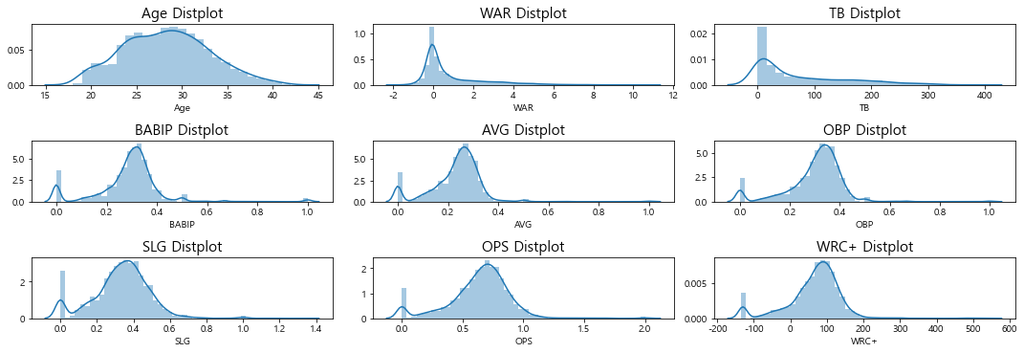

```python
def multi_distplot(df, records, figsize = [15, 15]):
    plt.rcParams['figure.figsize'] = figsize

    for idx, record in enumerate(records):
        plt.subplot(len(records), len(records)//3, idx+1)
        plt.title(record+' Distplot', fontsize=15)
        sns.distplot(df[record])

    plt.tight_layout()
    plt.show()

multi_distplot(batter_df2, ['Age','WAR','TB','BABIP','AVG','OBP','SLG','OPS','WRC+'])
```

각 수치형 변수의 Distplot을 확인해 본 결과, Age 변수의 경우 이상치 없이 근사적인 정규분포 형태를 가지는 것을 확인할 수 있습니다. 반면 그 외의 다른 수치형 변수들은 모두 이상치를 포함하고 있는 것으로 확인됩니다. 특히 대부분의 수치형 변수들 모두 0에 가까운 값에 이상치를 많이 포함하고 있으며, WRC+ 변수의 경우 -100 정도에 이상치를 많이 포함하고 있는 것으로 보여집니다. 그러나 이 변수들 모두 중심에서 많이 벗어나는 큰 값들과 0과 -100 근처의 이상치들을 제거한다면 전체적으로 정규분포 형태를 따를 것으로 보여집니다.

#### - 이상치 제거를 위한 데이터 특성 이해

좀 더 자세한 비교를 위해 이상치가 없는 Age 변수를 제외한 나머지 변수들을 scale이 비슷한 값끼리 묶어 Boxplot을 확인합니다.

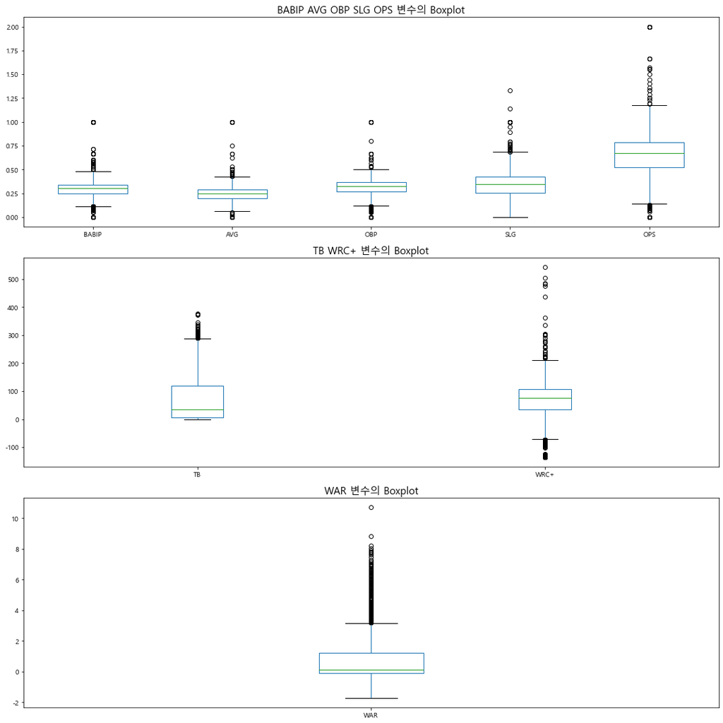

```python
def multi_boxplot(df, records, figsize = [15, 15]):
    plt.rcParams['figure.figsize'] = figsize

    for idx, record in enumerate(records):
        plt.subplot(len(records), len(records)//3, idx+1)
        plt.title(' '.join(record) + ' 변수의 Boxplot', fontsize=15)
        df.boxplot(record, grid=False)

    plt.tight_layout()
    plt.show()

multi_boxplot(batter_df2, [['BABIP','AVG','OBP','SLG','OPS'],['TB','WRC+'],['WAR']])
```

Distplot과 Boxplot에서 확인한 바와 같이 대부분의 수치형 변수들이 중심에서 벗어나는 이상치를 많이 가지고 있고, 이 값들만 제거된다면 전체적으로 정규분포 형태를 따를 것으로 보여집니다. 하지만 이상치 제거 이전에, 그래프와 데이터셋에 나타난 모든 이상치가 '존재할 수 없는 야구 기록'은 아니라는 점을 고려해야 합니다. 이상치로 보이는 값이더라도 그 선수가 평소와 달리 그해 슬럼프를 겪어 최악의 성적을 낸 경우도 존재할 것이고, 반대로 2014년의 서건창 선수와 같이 단일 시즌 안타 신기록을 작성한 경우도 있기 때문입니다. 그렇기 때문에 야구 기록 분석에 있어 이상치 처리시, 단순하게 특정값 이상/이하의 값들을 무조건 이상치로 판단하고 제거하는 것은 좋은 방법이 아닙니다.

우선, **야구 기록에서 대부분의 이상치는 주전 선수에 비해 후보 선수 혹은 대체선수들의 경기 출장횟수가 매우 적기 때문에 발생**합니다. 야구 기록은 대부분이 비율로써 계산되기 때문에 선수들의 표본이 적을 수록 극단적인 값을 가질 가능성이 높아집니다. 예를 들어, A 선수가 한 시즌 동안 300 타수 100안타를 치면 3할3푼3리의 타율을 가지게 되지만, B선수가 한 시즌 동안 1타수 1안타를 치면 그 선수의 타율은 10할로 기록됩니다. 하지만 그렇다고 해서 이 기록만 보고 B선수가 A선수보다 잘한다고 절대 말할 수 없습니다.

그렇기 때문에 야구 기록 분석에 있어 이러한 표본 문제들을 고려하기 위해 **'규정타석'** 이라는 자격기준이 존재합니다. 즉, 일정 타석 이상 출전한 선수들에게만 평가받을 자격을 부여하는 것 입니다. 따라서 본 분석에서도 선수들의 출장 타석 수(PA)를 기준으로 하여, 이상치를 포함하고 있을 가능성이 매우 높은 규정타석 이하의 선수들을 제거하는 방식으로 데이터셋 내의 이상치를 제거합니다.

#### - 이상치 제거를 위한 PA 변수의 요약통계량 확인

앞선 변수선택 과정에서 PA 변수는 WRC+와 상관관계가 비교적 낮아 선정되지 못했습니다. 따라서 변수 선택 과정 직전의 데이터프레임에서 PA 변수를 추출하는 과정이 필요합니다. 추가적으로, 2021년의 경우 아직 리그가 진행 중이기 때문에, 다른 시즌과 동일한 타석 기준으로 나눌 수 없습니다. 그래서 2021년과 2021년 이전으로 나누어 PA 변수의 요약통계량을 확인해 이상치 기준을 설정합니다.

```python
print('< 2021년 이전 PA (타석) 요약통계량 >')
print(batter_df[(batter_df.Season < 2021)].PA.describe())
print()
print('< 2021년 PA (타석) 요약통계량 >')
print(batter_df[(batter_df.Season == 2021)].PA.describe())

median1 = batter_df[(batter_df.Season < 2021)].PA.median()
median2 = batter_df[(batter_df.Season == 2021)].PA.median()
```

```
< 2021년 이전 PA (타석) 요약통계량 >
count    2655.000000
mean      208.404520
std       194.799988
min         1.000000
25%        32.000000
50%       135.000000
75%       379.500000
max       672.000000
Name: PA, dtype: float64

< 2021년 PA (타석) 요약통계량 >
count    188.000000
mean      53.148936
std       38.119838
min        2.000000
25%       17.500000
50%       46.000000
75%       92.250000
max      121.000000
Name: PA, dtype: float64
```

#### - 이상치 제거

요약통계량을 확인한 결과, 표준편차가 각각 194와 38로 크고, 최소값과 최대값 간 차이도 상당히 큰 것으로 나타났습니다. 이 경우, 평균은 극단값의 영향을 쉽게 받기 때문에 이상치 제거 기준으로 적합하지 않습니다. 따라서 PA변수의 중위수를 사용해, 2021년 이전 데이터는 135 타석을 2021년은 46 타석을 기준으로 이상치 제거를 수행합니다.

```python
idx1 = batter_df[(batter_df.Season < 2021) & (batter_df.PA < median1)].index
idx2 = batter_df[(batter_df.Season == 2021) & (batter_df.PA < median2)].index

drop_idx = batter_df2[batter_df2.index.isin(idx1) | batter_df2.index.isin(idx2)].index

batter_df2 = batter_df2.drop(drop_idx)
```

#### - 이상치 제거 확인

타석 기준에 따라 이상치가 올바르게 제거 되었는지 확인하고 index를 재설정합니다. 아래 Distplot을 보면 이상치가 깔끔하게 제거되어 모두 정상적인 분포 형태를 나타내고 있는 것을 확인할 수 있습니다.

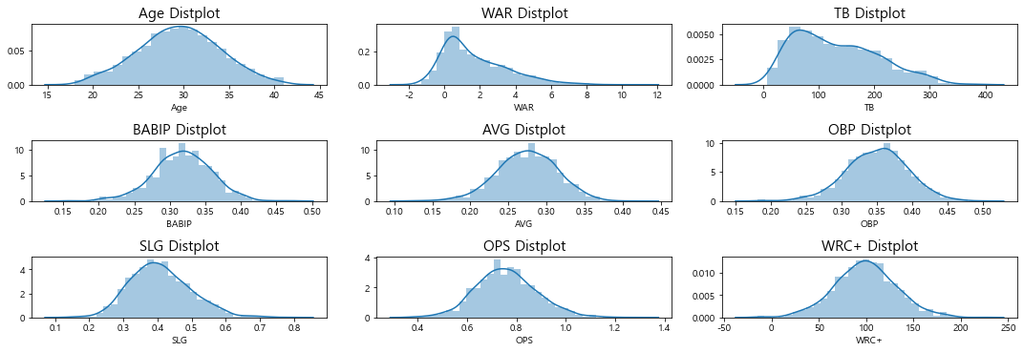

```python
batter_df2.reset_index(inplace=True, drop=True)
multi_distplot(batter_df2, ['Age','WAR','TB','BABIP','AVG','OBP','SLG','OPS','WRC+'])
```

정제된 수치형 변수들을 살펴보면, 대부분 근사적인 정규분포 형태를 띄고 있는 것을 확인할 수 있습니다. Age 변수의 경우 당연하게도 정규분포를 따르며 전체 리그에서 평균적으로 30살의 선수가 가장 많이 나타나는 것을 확인 할 수 있습니다. 그리고 BABIP의 경우 전체적으로 약 0.32의 평균을 가지는 것으로 보여집니다. 앞서 파생변수 생성과정에서 BABIP은 선수와 시즌마다 천차만별이나, 거시적인 관점에서 평균으로 수렴하는 경향이 있다고 언급한바 있습니다. 따라서 위 결과 역시 이러한 변수의 특징을 잘 나타낸다고 말할 수 있습니다.

가장 고전적인 타격 기록인 AVG, OBP, SLG를 살펴보면 각각 0.28, 0.37, 0.4를 중심으로한 분포를 띄고 있습니다. **일반적으로 강타자라고 평가받는 기준이 0.3 / 0.4 / 0.5인 것을 감안하면, 데이터셋 내의 대부분의 타자가 그 보다는 수준이 떨어진다고 할 수 있습니다.** OPS변수는 OBP+SLG로 계산되는 값이기 때문에 0.75를 중심으로한 분포를 가지며, 역시 정규분포가 가진 특징을 잘 드러낸다고 할 수 있습니다. 마지막으로 WRC+ 변수는 해당 세이버메트릭스 지표가 고안되는 과정에서 평균이 100을 가지도록 만들어졌습니다. 따라서 WRC+ 변수가 위와 같이 100을 중심으로한 정규분포 형태를 띄는 것은 당연하다고 할 수 있습니다.

다만 WAR과 TB 변수의 경우 정규분포를 따른다고 하기는 다소 어렵습니다. 우선 TB (총루타) 변수에서 이런 비대칭 분포가 나타나는 이유는 KBO 리그의 변화와 관련있는데, 데이터셋이 수집된 기간(2010~2021) 동안의 시즌별 전체 경기 횟수가 동일하지 않기 때문입니다. TB는 '안타 + 2x2루타 + 3x3루타 + 4x홈런'으로 계산되는 값으로, 당연히 경기 출장 횟수가 증가하면 그 값이 증가할 수 밖에 없습니다. 그렇기 때문에 아직 시즌이 진행 중인 올해는 TB값이 낮게 나올 수 밖에 없고, 이전 시즌들 역시 2013년과 2015년의 신생팀 창단을 기점으로 전체 경기 수가 계속 변했기 때문에, TB값의 분포가 시즌마다 달라질 수 밖에 없습니다. 그러다보니 본 데이터셋에서 TB 변수는 위와 같이 비대칭적인 분포가 나타날 수 밖에 없다고 할 수 있습니다.

다음으로 WAR 분포는 지표의 해석 관점에서 접근해 볼 수 있습니다. WAR이라는 지표는 대체선수 대비 승리기여도를 의미하는 값으로, 직관적으로 선수들의 기량을 평가하기 적합한 지표입니다. **WAR이 위 분포와 같이 0 ~ 2 사이에 선수들이 많이 분포해 있다는 것은 데이터셋 내의 선수들의 기량이 대체적으로 떨어진다는 것을 의미**하는데, 앞서 살펴본 AVG, OBP, SLG 변수에서도 이런 특징이 나타났다는 점을 상기할 필요가 있습니다.

WAR에 대한 좀 더 직관적인 이해를 위해, 위 분포에서 이상치 처럼 보이는 8이 넘는 WAR을 기록한 선수들의 명단을 살펴보겠습니다.

```python
batter_df2[batter_df2.WAR > 8]
```

|  | Name | Season | Age | Team | Position | WAR | TB | BABIP | AVG | OBP | SLG | OPS | WRC+ |
| --- | --- | --- | --- | --- | --- | --- | --- | --- | --- | --- | --- | --- | --- |
| 0 | 이대호 | 2010 | 28 | 롯데 | 3B | 8.82 | 319 | 0.361 | 0.364 | 0.444 | 0.667 | 1.111 | 192.4 |
| 207 | 강정호 | 2012 | 25 | 키움 | SS | 8.23 | 244 | 0.331 | 0.314 | 0.413 | 0.560 | 0.973 | 179.8 |
| 427 | 강정호 | 2014 | 27 | 키움 | SS | 8.05 | 309 | 0.398 | 0.356 | 0.459 | 0.739 | 1.198 | 185.6 |
| 536 | 테임즈 | 2015 | 29 | NC | 1B | 10.71 | 373 | 0.390 | 0.381 | 0.498 | 0.790 | 1.288 | 222.3 |

표에서 나타난 이대호, 강정호, 테임즈 이 세 선수들은 모두 압도적인 실력으로 KBO를 폭격한 뒤, MLB로 진출한 선수들입니다. 야구에 관심이 없더라도 한번쯤은 들어봤을 법한 선수들로, 이 정도의 수준을 가져야만 메이저 리그의 타자들과 경쟁이 가능하다라는 것을 알 수 있습니다. 그리고 실제로도 선수 스카우팅 과정에서 KBO의 수준은 MLB에 비해 AAA ~ AA 수준 (1, 2단계 아래)으로 평가받는 점을 고려해보면, KBO 타자들의 기록을 수집한 본 데이터셋에서 위와 같이 WAR 분포가 오른쪽으로 꼬리가 긴 비대칭형 분포로 나오는 것은 오히려 데이터의 특성을 정확하게 나타내는 것이라고 할 수 있습니다.

#### - 최종 데이터셋 확인

정제된 데이터셋의 수치형 변수들에 문제가 없다는 것을 확인했으니, 최종적으로 분석에 사용할 데이터셋을 다시한번 확인하겠습니다.

```python
batter_df2
```

|  | Name | Season | Age | Team | Position | WAR | TB | BABIP | AVG | OBP | SLG | OPS | WRC+ |
| --- | --- | --- | --- | --- | --- | --- | --- | --- | --- | --- | --- | --- | --- |
| 0 | 이대호 | 2010 | 28 | 롯데 | 3B | 8.82 | 319 | 0.361 | 0.364 | 0.444 | 0.667 | 1.111 | 192.4 |
| 1 | 조인성 | 2010 | 35 | LG | C | 5.96 | 255 | 0.333 | 0.317 | 0.374 | 0.558 | 0.932 | 140.0 |
| 2 | 김현수 | 2010 | 22 | 두산 | LF | 5.24 | 251 | 0.321 | 0.317 | 0.414 | 0.531 | 0.945 | 152.0 |
| 3 | 홍성흔 | 2010 | 33 | 롯데 | DH | 5.15 | 259 | 0.346 | 0.350 | 0.427 | 0.601 | 1.028 | 171.9 |
| 4 | 최정 | 2010 | 23 | SSG | 3B | 5.07 | 213 | 0.316 | 0.300 | 0.396 | 0.533 | 0.929 | 138.8 |
| ... | ... | ... | ... | ... | ... | ... | ... | ... | ... | ... | ... | ... | ... |
| 1422 | 이천웅 | 2021 | 33 | LG | CF | -0.13 | 13 | 0.205 | 0.167 | 0.250 | 0.241 | 0.491 | 34.6 |
| 1423 | 손아섭 | 2021 | 33 | 롯데 | RF | -0.16 | 30 | 0.298 | 0.257 | 0.331 | 0.275 | 0.606 | 67.8 |
| 1424 | 프레이타스 | 2021 | 32 | 키움 | DH | -0.19 | 34 | 0.299 | 0.261 | 0.289 | 0.370 | 0.658 | 74.5 |
| 1425 | 이성열 | 2021 | 37 | 한화 | DH | -0.39 | 6 | 0.207 | 0.158 | 0.283 | 0.158 | 0.441 | 29.0 |
| 1426 | 임종찬 | 2021 | 20 | 한화 | RF | -0.40 | 15 | 0.222 | 0.148 | 0.235 | 0.246 | 0.481 | 25.7 |

1427 rows × 13 columns

데이터 클린징 작업을 통해 최종적으로 정제된 데이터셋은 총 1427개 행, 13개의 열을 가진 데이터셋입니다. 최종적으로 선정된 변수에 대한 설명을 정리하면 다음과 같습니다.

- 범주형 변수
  - Name : 선수 이름
  - Season : 년도
  - Team : 소속 구단
  - Position : 포지션
- 수치형 변수
  - Age : 나이
  - WAR : 대체선수 대비 승리기여도 (세이버메트릭스 지표)
  - TB : 총루타
  - BABIP : 인플레이 타구의 타율 (세이버메트릭스 지표)
  - AVG : 타율
  - OBP : 출루율
  - SLG : 장타율
  - OPS : 출루율 + 장타율
  - WRC+ : 조정 득점 생산력 (세이버메트릭스 지표)

## 4. 데이터 탐색

수치형 변수의 경우 앞선 이상치 처리 과정을 통해 변수들의 전체적인 분포와 특징들을 살펴보았기 때문에 본 과정에서는 범주형 변수들에 집중하여 데이터 탐색을 수행합니다.

#### - 빈도분석

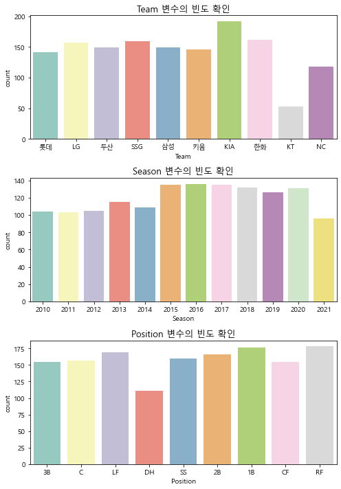

```python
sns.set_palette("Set3")

def multi_countplot(df, records, figsize = [7, 10]):
    plt.rcParams['figure.figsize'] = figsize

    for idx, record in enumerate(records):
        plt.subplot(len(records), len(records)//3, idx+1)
        plt.title(''.join(record) + ' 변수의 빈도 확인', fontsize=13)
        sns.countplot(record,data=batter_df2)

    plt.tight_layout()
    plt.show()

multi_countplot(batter_df2, ['Team','Season', 'Position'])
```

우선 여러 범주형 변수들 중 각 구단을 나타내는 Team 변수를 살펴보면, 2015년에 창단된 신생팀인 KT 위즈의 경우, 다른 팀에 비해 데이터셋 내에 선수 숫자가 많이 적은 것을 확인할 수 있습니다. 비슷하게 2013년 창단한 NC 다이노스 역시 다른 팀에 비해 선수 빈도가 적으나, KT 보다는 좀 더 오래되었기 때문에 비교적 그 빈도의 차이가 크지 않은 것으로 보여집니다.

Season 변수의 경우, 2021년의 빈도수가 가장 적게 나타나고 있습니다. 이는 아직 시즌이 진행 중이라서 선수 데이터가 완전히 집계된 것이 아니기 때문에 나타나는 것으로 보여집니다.

마지막으로 Position 변수의 경우, 대부분의 포지션이 고르게 나타나고 있으나 **지명타자 (DH)** 의 빈도가 유독 적게 나타나는 것으로 확인됩니다. 타 포지션에 비해 지명타자로 출전한 선수가 적은 이유는, 현대 야구의 스타일 변화를 통해 접근해 볼 수 있습니다. 지명타자 포지션은 타포지션과 달리 수비에 참여하지 않지만, 뛰어난 장타력과 홈런 생산성으로 팀의 공격력을 책임지는 포지션입니다. 대표적으로 2002년 삼성 라이온즈를 우승으로 이끌었던 '이마양 트리오' 중 한명인 마해영, 롯데 자이언츠의 홍성흔, 기아 타이거즈의 나지완 등과 같이 각 팀을 대표하는 거포들을 위한 포지션이었습니다.

하지만 2010년대에 들어서면서 외국인 타자 제도가 재도입되고 NC, KT 두 신생팀이 창단하면서 시즌당 경기 횟수가 증가함에 따라, 타자들의 타격능력 외에도 수비능력 역시 중요해지게 되었습니다. 그로 인해 자연스럽게 지명타자 포지션에 대한 인식은 수비도 못하면서 주전 엔트리를 낭비하는 반쪽짜리 선수라는 인식이 강해졌고, 그 결과 과거와 같은 '전문 지명타자'라는 개념은 거의 사라지게 되었습니다. 따라서 이러한 변화로 인해 Position 변수에서 다른 포지션에 비해 지명타자의 빈도가 유독 적게 나타나는 것이라고 할 수 있습니다.

#### - 교차분석

다음으로 각 포지션별 WRC+를 비교하여 어느 포지션이 득점 생산성이 좋은지 확인해보겠습니다.

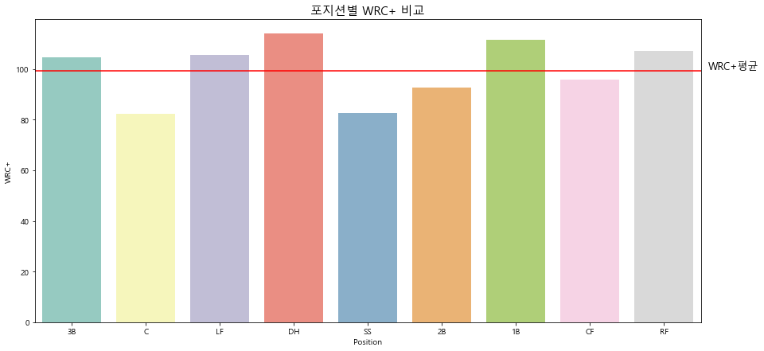

```python
plt.rcParams['figure.figsize'] = (15, 7)
plt.title('포지션별 WRC+ 비교', fontsize=15)
sns.barplot(batter_df2.Position, batter_df2['WRC+'], data=batter_df2,ci=None)
plt.axhline(y=batter_df2['WRC+'].mean(), color='r', mew=5)
plt.text(8.6, 100, 'WRC+평균', fontsize=13)
plt.show()
```

위 Barplot을 보면, **지명타자 (DH), 1루수 (1B), 3루수 (3B), 좌익수 (LF), 우익수 (RF)**는 WRC+가 100 이상의 값을 나타나는 것으로 확인되었습니다. **즉, 이 포지션을 맡은 선수들은 다른 포지션에 비해 득점 생산성이 좋다는 것을 의미합니다.** 해당 포지션들에서 득점 생산성이 높게 나타나는 이유는, 이 포지션에 거포들이 주로 포진되기 때문입니다. 거포형 선수들은 공을 멀리 보내기 위해 근육과 몸집을 키우는 경향이 있어 대체로 움직임이 민첩하지 않습니다. 하지만, 수비 포지션 중 센터라인(포수-2루수/유격수-중견수)은 처리하기 까다로운 타구가 많이 발생하여 수비시 뛰어난 반사신경을 요구하는 포지션입니다. 따라서 민첩성이 떨어지는 거포형 선수들이 맡기에는 위험성이 크기 때문에, 아예 수비에 참여하지 않는 지명타자나 비교적 수비부담이 적은 1루수/3루수, 좌익수/우익수 포지션을 할당하여 수비 부담을 덜어주는 것이라고 할 수 있습니다.

## 5. 데이터 분석

이제, 수집한 데이터셋에 대한 전처리와 데이터 탐색이 모두 끝났으니 본격적인 데이터 분석을 진행합니다.

### 삼성 라이온즈의 잃어버린 5년

삼성 라이온즈는 2010년 부터 2015년 까지 한국시리즈 6년 연속 진출, 통합 4연패, 정규시즌 5연패를 달성한 한국 프로야구 역사상 최고의 강팀이었습니다. 하지만 어떤 이유에서인지 2016년을 기점으로 급속도로 몰락하여 2020년까지 9위, 9위, 6위, 8위, 8위라는 명성에 맞지 않는 초라한 성적을 남기게 되었습니다. 그렇다면 왜 삼성 라이온즈는 한순간에 몰락하게 되었는지, 암흑기 동안의 삼성 라이온즈 타선의 실체를 파악해보겠습니다.

#### - 데이터셋 분리, 병합

먼저, 추후 편리한 분석을 위해 데이터셋에 대한 분리, 병합 작업을 수행합니다.

```python
df1 = batter_df2[(batter_df2.Season <= 2015)]
check = (df1.Team == 'KT') | (df1.Team == 'NC')

df1 = df1[~check]
df2 = batter_df2[(batter_df2.Season >= 2016) & (batter_df2.Season <= 2020)]
df3 = batter_df2[batter_df2.Season == 2021]
df3.loc[1356, 'Team'] = 'KT'

sam1 = df1[df1.Team == '삼성']
sam2 = df2[df2.Team == '삼성']
sam3 = df3[df3.Team == '삼성']

oh = batter_df2[batter_df2.Name == '오재일']
df2021 = pd.concat([sam3['WRC+'], oh[oh.Season==2020]['WRC+']])
samsung = pd.concat([sam1,sam2,sam3])
```

#### - 구단별 기록 분석 : 전성기 2010 ~ 2015

가장 먼저 2010년부터 2015년까지 삼성 라이온즈가 독주체제를 갖추던 시절의 타격 기록을 살펴보겠습니다. 이 기간 동안 2013년에 1군 리그에 진입한 NC 다이노스와 2015년 창단한 KT 위즈는 표본이 적기 때문에 분석에서 제외했습니다.

```python
def h_max(s):
    is_max = s == s.max()
    return ['background-color: yellow' if v else '' for v in is_max]

df1.groupby(df1.Team).mean().style.apply(h_max)
```

| Team | Age | WAR | TB | BABIP | AVG | OBP | SLG | OPS | WRC+ |
| --- | --- | --- | --- | --- | --- | --- | --- | --- | --- |
| KIA | 29.336957 | 1.495543 | 115.739130 | 0.310043 | 0.266663 | 0.347696 | 0.392065 | 0.739750 | 94.793478 |
| LG | 29.734177 | 1.658101 | 121.088608 | 0.317848 | 0.271734 | 0.347278 | 0.385646 | 0.732873 | 97.469620 |
| SSG | 30.160494 | 1.713951 | 125.049383 | 0.312593 | 0.268704 | 0.345568 | 0.400938 | 0.746605 | 98.041975 |
| 두산 | 27.800000 | 2.126000 | 130.387500 | 0.314938 | 0.279813 | 0.357750 | 0.409413 | 0.767275 | 107.656250 |
| 롯데 | 28.700000 | 2.266000 | 151.100000 | 0.323086 | 0.278571 | 0.349329 | 0.414600 | 0.763914 | 102.507143 |
| 삼성 | 29.383562 | 2.526164 | 146.424658 | 0.321301 | 0.281315 | 0.364027 | 0.418425 | 0.782356 | 109.247945 |
| 키움 | 28.893333 | 2.037200 | 139.653333 | 0.311987 | 0.268827 | 0.347760 | 0.412187 | 0.759947 | 99.889333 |
| 한화 | 30.185185 | 1.302593 | 109.370370 | 0.308247 | 0.259975 | 0.341272 | 0.372173 | 0.713370 | 88.617284 |

삼성 왕조로 불리며 리그의 최강자로 군림했던 2010년 ~ 2015년의 삼성 라이온즈의 타격기록을 살펴보면, WAR, AVG, OBP, OPS, WRC+ 부분에서 리그 1위의 성적을 내고 있는 것을 확인할 수 있습니다. 또한 TB, BABIP 역시 롯데 자이언츠와 근소한 차이로 2위에 위치하며 당시 최강팀의 면모를 잘 보여주고 있습니다. 이 기간 동안 최약팀은 모든 타격 지표에서 최소값을 차지하고, 선수단 나이마저 가장 많았던 한화 이글스였습니다.

```python
df1.sort_values('WAR', ascending=False).head(60).Team.value_counts()
```

```
삼성     13
롯데     12
키움     11
KIA     6
LG      6
두산      4
SSG     4
한화      4
Name: Team, dtype: int64
```

특히 승리 기여도를 나타내는 WAR 상위 60명(데이터셋의 10%에 해당)에 해당하는 선수들의 소속구단을 확인해보면, 삼성 라이온즈 소속 선수가 가장 많이 나타난 것을 확인할 수 있습니다. 이러한 점들을 종합해보면 전성기 시절의 삼성 라이온즈 타선이 얼마나 위력적이었는지를 알 수 있습니다.

#### - 구단별 기록 분석 : 암흑기 2016 ~ 2020

그러나 철옹성과 같았던 삼성 왕조는 2016년을 기점으로 무너지기 시작합니다. 삼성 라이온즈가 몰락한 이후, 리그 최강팀의 자리는 아래 표와 같이 BABIP을 제외한 모든 타격 지표에서 1위를 차지한 두산 베어스가 이어 받았습니다. 그에 비해 삼성은 모든 타격 지표가 전성기 시절에 비해 후퇴하며, 전력 약화를 드러내고 있습니다.

```python
df2.groupby(df2.Team).mean().style.apply(h_max)
```

| Team | Age | WAR | TB | BABIP | AVG | OBP | SLG | OPS | WRC+ |
| --- | --- | --- | --- | --- | --- | --- | --- | --- | --- |
| KIA | 30.122222 | 1.524222 | 144.644444 | 0.319700 | 0.280722 | 0.348767 | 0.419789 | 0.768544 | 95.068889 |
| KT | 29.475000 | 1.882500 | 164.250000 | 0.322725 | 0.277700 | 0.345125 | 0.423875 | 0.769000 | 100.165000 |
| LG | 29.985294 | 1.671471 | 139.750000 | 0.326956 | 0.281868 | 0.348868 | 0.408926 | 0.757912 | 98.883824 |
| NC | 30.277778 | 1.775833 | 142.541667 | 0.320361 | 0.281306 | 0.353486 | 0.426417 | 0.779931 | 101.365278 |
| SSG | 30.264706 | 1.446029 | 143.720588 | 0.311368 | 0.272397 | 0.344000 | 0.427088 | 0.771118 | 95.927941 |
| 두산 | 29.677966 | 2.846271 | 179.559322 | 0.326441 | 0.293119 | 0.367559 | 0.444441 | 0.812017 | 113.654237 |
| 롯데 | 29.781250 | 1.600000 | 147.687500 | 0.320703 | 0.272266 | 0.345219 | 0.410438 | 0.755625 | 94.356250 |
| 삼성 | 29.582090 | 1.437910 | 144.343284 | 0.315313 | 0.276164 | 0.343925 | 0.412478 | 0.756433 | 93.413433 |
| 키움 | 27.354839 | 2.146774 | 160.612903 | 0.334081 | 0.285403 | 0.357468 | 0.433613 | 0.791097 | 105.430645 |
| 한화 | 30.242857 | 1.104000 | 126.800000 | 0.322400 | 0.270671 | 0.338314 | 0.394486 | 0.732771 | 88.984286 |

우선 삼성 라이온즈가 암흑기로 접어든 이 기간 동안 AVG, OBP, SLG, OPS로 대표되는 기초적인 타격 지표들의 변화를 살펴보면, AVG는 0.005, OBP는 0.02, SLG는 0.006, OPS는 0.03이 감소한 것으로 나타납니다. 전반적으로 팀 타격 지표가 떨어졌기 때문에 선수들의 기량이 저하되었다고 판단할 수는 있으나, 그 감소 폭이 유의미하다고 생각될 만큼 크지는 않습니다. 따라서 이 지표들의 변화만으로 삼성 라이온즈가 1년만에 1위에서 9위로 급격히 추락했던 이유를 설명 하기에는 부족합니다. 하지만 나머지 **WAR, BABIP, WRC+** 이 세 세이버메트릭스 지표의 변화를 살펴보면, 추락의 원인에 대한 해답을 찾을 수 있습니다.

- WAR

WAR을 살펴보면 2016년 이후 삼성의 WAR 평균은 2.5에서 1.4로 반토막이 났습니다. WAR은 대체선수 대비 승리기여도를 의미하는 값으로, 여기서는 대체선수로만 구성된 팀에 비해 해당 구단의 타자들이 얼마만큼의 승리를 더 얻었는지를 나타냅니다. 앞서 변수 소개 과정에서 WAR이 0-2 사이의 값이면 후보선수, 2-6이면 주전선수로 구분할 수 있다고 언급한 바 있습니다. **즉, 1.4라는 WAR 값은 암흑기 기간 동안의 삼성 라이온즈 타자들은 후보 선수 수준의 선수들로 구성된 팀이었다는 것을 보여주는 값입니다.** 특히 앞서 살펴봤던 2010-2015년도 최약체 구단인 한화 이글스의 WAR 평균이 1.3 이었다라는 점을 감안해 보면, 암흑기 동안 삼성 라이온즈 타자들의 수준이 어느 정도로 추락했는지 잘 드러납니다.

실제로 2015년 이후 삼성 라이온즈는 팀의 핵심 타자였던 이승엽, 최형우, 박석민, 나바로 등이 은퇴와 FA 이적으로 팀을 떠나면서 세대교체의 필요성이 대두되었습니다. 하지만 구자욱을 제외하고는 뚜렷한 타자 유망주를 길러내지 못했고, FA를 통한 외부 수혈에도 소극적으로 나서면서 팀의 뎁스는 급격히 약화되었습니다. 미진한 세대교체와 줄어든 투자는 타선의 약화를 가속화했고, 주전 엔트리를 기존의 백업 선수들로 대체할 수 밖에 없는 악순환으로 이어지게 되었습니다. 그리고 결국 그 결과가 위와 같이 1.4의 WAR값으로 나타는 것이라고 할 수 있습니다.

- BABIP

다음으로 BABIP을 살펴보면, 0.315로 SSG 랜더스(당시 SK 와이번스)가 기록한 리그 최저치인 0.311과 거의 비슷한 값을 가지는 것을 볼 수 있습니다. 타율이 0.281에서 0.276으로 감소했기에 인플레이 타율을 나타내는 BABIP 역시 감소한 점은 당연하다고 볼 수 있습니다. 이런 BABIP의 감소를 단순하게 운이 나빴기 때문에 라고 해석할 수도 있지만, KBO리그 특성과 암흑기 동안의 삼성 타자들이 후보선수 수준의 타자들이 었다는 점을 생각해보면 BABIP 수치 감소를 다르게 살펴볼 필요가 있습니다.

- WRC+

마지막으로, 팀의 승리와 상관관계가 가장 높았던 WRC+ 역시 109에서 93으로 눈에 띄게 감소한 것을 확인할 수 있습니다. 93이라는 수치는 리그평균인 100 대비 -7%의 득점 생산성을 의미합니다. 이는 타자들이 타석에 들어서서 평균보다 7%나 점수를 못냈다는 것으로, 주자가 누상에 출루를 하여도 후속 타자들이 득점으로 전혀 연결을 시키지 못했다는 것을 의미합니다. **즉, 득점권 상황에서 확실하게 득점을 만들어 줄 수 있는 생산성 있는 타자가 팀에 없었거나, 상위 타선과 하위 타선 간의 격차가 극심했다고 해석할 수 있습니다.** 이렇듯 타자들이 평균보다 7%나 점수를 못내니 이길 수 있는 경기도 이길 수가 없었을 것이고 순위 역시 하위권에 머물 수 밖에 없었을 것입니다.

이 결과들을 종합해보면, 암흑기 동안의 삼성 라이온즈의 타선은 다음과 같은 특징을 보인다고 할 수 있습니다.

1. 주전 타자들의 기량이 후보 선수 수준과 다름 없었다.
2. 타자들이 좋은 안타성 타구를 전혀 만들지 못했다.
3. 출루를 해도 득점으로 이어줄 생산성 있는 타자가 없었다.

## 6. 데이터 시각화

### 타선의 구멍은 어디에?

앞서 살펴본 것과 같이 암흑기 동안의 삼성 라이온즈 타선은 안타도 못치고, 득점도 제대로 못하는 후보선수 수준의 타자들로 이루어진 허수아비 타선이었습니다. 하지만 구단의 모든 타자들이 제 몫을 못한 것은 아닐 것입니다. 그렇다면 타선에서 정확히 어디가 문제였던 것인지 데이터 시각화를 통해 알아보겠습니다.

#### - 허수아비 타선의 실체

우선 암흑기 동안의 삼성 라이온즈 타자들의 상황을 좀 더 자세히 알아보기 위해, 출루 기록을 가늠해 볼 수 있는 TB (총루타) 값에 대한 Violinplot을 확인해 보겠습니다. TB (총루타)는 '안타 + 2x2루타 + 3x3루타 + 4x홈런'으로 계산되는 값으로, 타자의 타격 기록을 대략적으로 살펴볼 수 있는 값입니다. 계산식에서 보이는 것과 같이, 장타가 많을수록 TB값은 증가합니다.

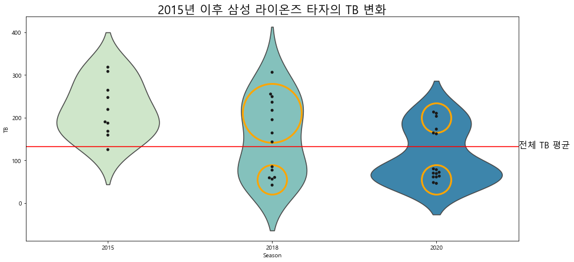

```python
plt.title('2015년 이후 삼성 라이온즈 타자의 TB 변화', fontsize=20)
sns.violinplot(x='Season', y='TB', data=samsung[(samsung.Season == 2015) | (samsung.Season == 2018) |
                                                (samsung.Season == 2020)], orient='v', inner=None, palette='GnBu')
sns.swarmplot(x='Season', y='TB', data=samsung[(samsung.Season == 2015) | (samsung.Season == 2018) |
                                                (samsung.Season == 2020)], color='0.1')

plt.text(2.5, 130, '전체 TB 평균', fontsize=15)
plt.plot(1, 210, 'o', ms= 50* 2, mec='Orange', mfc='none', mew=3)
plt.plot(1, 55, 'o', ms= 25* 2, mec='Orange', mfc='none', mew=3)
plt.plot(2, 200, 'o', ms= 25* 2, mec='Orange', mfc='none', mew=3)
plt.plot(2, 55, 'o', ms= 25* 2, mec='Orange', mfc='none', mew=3)
plt.axhline(y=batter_df2.TB.mean(), color='r')

plt.show()
```

위 그래프를 살펴보면 마지막 전성기인 2015년의 분포와 암흑기인 2018, 2020년 간의 차이가 극명하게 드러납니다. 2015년의 경우, 거의 모든 타자들이 평균 이상의 TB를 기록하며 뛰어난 장타 생산 능력을 보였습니다. 게다가 타자들간의 분포 역시 고르게 퍼져있어 선수들간의 기량 격차가 크지 않았다고 할 수 있습니다. 그에 비해 2018년과 2020년의 TB 분포를 살펴보면 점점 타자들의 기량이 떨어지는 것이 나타납니다. 그러나 무엇보다도 이 암흑기 기간 동안 가장 중요하게 봐야할 점은, **전체 평균을 기점으로 상하위 그룹이 극명**하게 나눠진다는 점입니다. 굳이 전체 평균으로 나누지 않고 Violinplot 자체로 살펴보아도, 단봉인 2015년에 비해 2018년과 2020년은 분포의 중심이 2군데로 나누어져서 나타나는 것을 확인할 수 있습니다.

특히 지난해 삼성 라이온즈의 TB 분포를 보면, 타선은 상위 그룹에 속한 **6명의 타자를 제외하고는 심각한 하향평준화**가 이루어진 것이 나타납니다. **즉, 상위 그룹의 6명의 선수가 팀 타선의 모든걸 책임지는 비정상적인 타선이라고 볼 수 있습니다.** 그리고 이러한 비정상적인 분포의 타선은, 역으로 상위 그룹에 속한 선수들이 부진할 경우 타선의 생산성 전체가 뿌리째 흔들릴 수 있다는 것을 의미합니다.

#### - 9개의 타순, 6명의 타자, 3개의 빈자리

야구는 공격시 3아웃 전까지 9명의 타자가 순서대로 돌아가며 타석에 들어섭니다. 하지만 앞서 살펴본 바에 의하면 지난해 삼성 라이온즈는 오직 6명의 선수만 제 몫을 해주었습니다. 그럼 타선에서의 나머지 3개의 구멍은 어디였는지, 다른 구단에 비해 얼마나 부족했는지 확인해 보겠습니다.

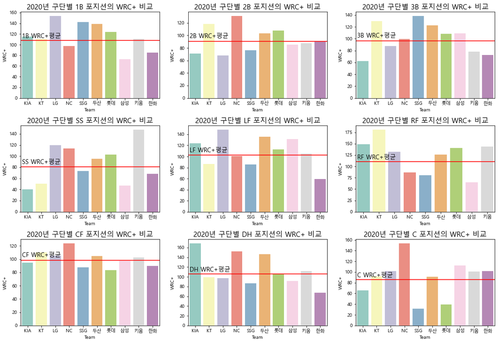

```python
def multi_barplot(df, position, figsize = [15, 30]):
    plt.rcParams['figure.figsize'] = figsize

    for idx, pos in enumerate(position):
        x = df[df.Position == pos].sort_values('Team')
        plt.subplot(len(position), len(position)//3, idx+1)
        plt.title('2020년 구단별 '+''.join(pos) + ' 포지션의 WRC+ 비교', fontsize=15)
        plt.axhline(y=x['WRC+'].mean(), color='r', mew=5)
        plt.text(-0.4, x['WRC+'].mean()+5, pos+' WRC+평균', fontsize=13)
        sns.barplot(x.Team, x['WRC+'], data=x, ci=None)

    plt.tight_layout()
    plt.show()

tmp = batter_df2[(batter_df2.Season == 2020)]
multi_barplot(tmp, ['1B','2B','3B','SS','LF','RF','CF','DH','C'])
```

위 Barplot 결과를 살펴보면 지난해 삼성 라이온즈는 **1루수(1B), 유격수(SS), 우익수(RF)** 정확히 3개의 포지션이 다른 구단에 비해 유독 취약한 것으로 드러났습니다. 특히, 이 세 포지션 중에서 1루수와 우익수에 주목할 필요가 있습니다. 앞선 교차분석에서 살펴본 바와 같이, 유격수와 달리 1루수와 우익수 포지션은 평균 이상의 높은 WRC+를 기록할 수 있는 뛰어난 득점 생산성을 가진 선수들이 주로 맡는 포지션이기 때문입니다.

하지만 지난해 삼성 라이온즈가 이 포지션에서 가장 낮은 WRC+를 기록했다는 것은, 팀에서 확실하게 득점을 내줄 수 있는 타자가 2명이나 부족했다는 것을 의미합니다. 장기로 비유하자면 차와 포를 버린 것과 같은데, 주요 득점 루트가 사실상 없는 것과 마찬가지이니 쉽게 말해 **득점을 못하는게 당연한 타선**이었다고 볼 수 있습니다. 그리고 이러한 **핵심 포지션에서의 공백**은 암흑기 동안의 WRC+가 93으로 나타나는 주 원인이 되었습니다.

따라서 삼성 라이온즈가 다시 부활하기 위해서는, 1루수와 우익수 두 핵심 포지션의 공백을 채우고, 극단적으로 하향평준화된 타선 불균형을 해소하는 것이 가장 중요해 보입니다. 이를 해결하기 위해서는 하위 그룹의 타자들이 성장해 상위 그룹으로 치고 올라오거나, 기량이 검증된 새 선수를 영입해 불균형을 줄이는 방법이 있을 것입니다. 다만 이 중에서, 하위 그룹의 선수들이 한순간에 상위 그룹 만큼의 기량을 가진다는 것은 현실적으로 불가능하므로, 실질적으로 이런 **타선 불균형 문제를 해결하기 위해서는 FA나 트레이드를 통한 외부 수혈**이 필요하다고 할 수 있습니다.

## 7. 삼성 라이온즈는 어떻게 다시 강팀이 되었나

### 불 붙은 타선 개혁

앞선 분석 결과들을 종합해보면 삼성 라이온즈가 다시 부활하기 위해서는 상위 그룹의 타자들에 대한 의존성을 줄이고, 떨어진 팀의 득점 생산력을 높여야 한다는 것을 알 수 있습니다. 결국 심각할 정도로 하향 평준화된 타선의 불균형을 어떻해서든 해소해야 하는데, 가장 손쉬운 방법은 외부 영입이었습니다.

구단 프론트 내에서도 이런 타선의 심각성을 인지했는지 지난 겨울 스토브 리그가 열리자 마자 삼성 라이온즈는 가장 빠르게 움직였습니다. 내부 FA인 '이원석', '우규민'과 빠르게 재계약을 체결하며 전력 유출을 막았고, FA 최대어로 뽑히던 두산 베어스의 '오재일'과 4년 50억에 계약하면서 거침없는 행보를 이어갔습니다. 또한 지난해 부상과 부진으로 제 활약을 못했던 외국인 타자 자리에 NPB에서 뛰던 '호세 피렐라'를 영입하며 침체된 타선 개혁에 불을 붙였습니다.

그렇다면 이러한 과감한 투자가 정말 의미 있는 변화로 이어졌는지, 결과적으로 강팀으로 나아갈 발판이 되었는지 확인해 보겠습니다.

#### - 우익수 : 효자 외인의 등장과 포지션 연쇄이동

앞서 암흑기 동안 삼성의 최대 약점으로 뽑혔던 우익수, 유격수, 1루수 중 우익수 포지션 부터 살펴보겠습니다.

```python
sam3.sort_values('WAR', ascending=False)
```

|  | Name | Season | Age | Team | Position | WAR | TB | BABIP | AVG | OBP | SLG | OPS | WRC+ |
| --- | --- | --- | --- | --- | --- | --- | --- | --- | --- | --- | --- | --- | --- |
| 1332 | 피렐라 | 2021 | 32 | 삼성 | LF | 1.46 | 70 | 0.346 | 0.356 | 0.404 | 0.673 | 1.077 | 178.8 |
| 1334 | 강민호 | 2021 | 36 | 삼성 | C | 1.38 | 52 | 0.412 | 0.393 | 0.447 | 0.619 | 1.066 | 184.6 |
| 1335 | 구자욱 | 2021 | 28 | 삼성 | RF | 1.35 | 56 | 0.370 | 0.333 | 0.421 | 0.583 | 1.004 | 165.5 |
| 1378 | 이학주 | 2021 | 31 | 삼성 | SS | 0.33 | 25 | 0.375 | 0.241 | 0.353 | 0.431 | 0.784 | 112.7 |
| 1387 | 김지찬 | 2021 | 20 | 삼성 | SS | 0.28 | 17 | 0.311 | 0.292 | 0.346 | 0.354 | 0.700 | 90.8 |
| 1394 | 박해민 | 2021 | 31 | 삼성 | CF | 0.23 | 29 | 0.288 | 0.264 | 0.340 | 0.319 | 0.658 | 75.7 |
| 1396 | 김상수 | 2021 | 31 | 삼성 | 2B | 0.15 | 23 | 0.260 | 0.222 | 0.346 | 0.256 | 0.601 | 73.1 |
| 1398 | 이원석 | 2021 | 35 | 삼성 | 1B | 0.14 | 24 | 0.255 | 0.221 | 0.333 | 0.353 | 0.686 | 85.6 |
| 1411 | 강한울 | 2021 | 30 | 삼성 | 3B | 0.05 | 17 | 0.349 | 0.246 | 0.347 | 0.279 | 0.626 | 77.4 |

삼성이 새롭게 영입한 외국인 타자 피렐라는 현재 0.356의 높은 타율과 1.077의 OPS, 178.8의 WRC+를 기록하며 절정의 타격감을 뽐내며 삼성의 좌익수 자리를 안정화 시키고 있습니다. 그리고 이러한 피렐라의 활약은 외야수 기용에서의 연쇄 이동을 일으켰는데, 피렐라로 인해 좌익수 자리가 고정되자 지난해 좌익수를 맡았던 구자욱이 원래 포지션인 우익수 포지션으로 이동하게 되었습니다.

```python
batter_df2[batter_df2.Name == '구자욱']
```

|  | Name | Season | Age | Team | Position | WAR | TB | BABIP | AVG | OBP | SLG | OPS | WRC+ |
| --- | --- | --- | --- | --- | --- | --- | --- | --- | --- | --- | --- | --- | --- |
| 545 | 구자욱 | 2015 | 22 | 삼성 | 1B | 4.99 | 219 | 0.407 | 0.349 | 0.417 | 0.534 | 0.951 | 148.4 |
| 694 | 구자욱 | 2016 | 23 | 삼성 | 1B | 3.96 | 234 | 0.379 | 0.343 | 0.420 | 0.547 | 0.967 | 142.5 |
| 815 | 구자욱 | 2017 | 24 | 삼성 | RF | 4.96 | 297 | 0.371 | 0.310 | 0.383 | 0.527 | 0.910 | 130.5 |
| 958 | 구자욱 | 2018 | 25 | 삼성 | RF | 3.91 | 255 | 0.397 | 0.333 | 0.392 | 0.533 | 0.926 | 131.9 |
| 1125 | 구자욱 | 2019 | 26 | 삼성 | RF | 1.98 | 211 | 0.296 | 0.267 | 0.327 | 0.444 | 0.771 | 107.8 |
| 1226 | 구자욱 | 2020 | 27 | 삼성 | LF | 3.35 | 213 | 0.355 | 0.307 | 0.385 | 0.478 | 0.863 | 125.9 |
| 1335 | 구자욱 | 2021 | 28 | 삼성 | RF | 1.35 | 56 | 0.370 | 0.333 | 0.421 | 0.583 | 1.004 | 165.5 |

그렇게 구자욱이 원래 포지션을 되찾으면서 더 안정적인 활약을 보여줄 수 있는 여건이 마련되었고, 그 결과 현재 구자욱이 1.004의 OPS와 165.5의 WRC+를 기록하며 좋은 컨디션을 보이는 원동력이 되었습니다.

```python
batter_df2[batter_df2.Name == '김헌곤']
```

|  | Name | Season | Age | Team | Position | WAR | TB | BABIP | AVG | OBP | SLG | OPS | WRC+ |
| --- | --- | --- | --- | --- | --- | --- | --- | --- | --- | --- | --- | --- | --- |
| 504 | 김헌곤 | 2014 | 26 | 삼성 | CF | 0.56 | 52 | 0.290 | 0.260 | 0.359 | 0.423 | 0.782 | 96.7 |
| 902 | 김헌곤 | 2017 | 29 | 삼성 | LF | 0.54 | 138 | 0.279 | 0.264 | 0.331 | 0.388 | 0.718 | 80.5 |
| 989 | 김헌곤 | 2018 | 30 | 삼성 | LF | 1.99 | 217 | 0.328 | 0.300 | 0.375 | 0.423 | 0.798 | 103.9 |
| 1133 | 김헌곤 | 2019 | 31 | 삼성 | LF | 1.69 | 159 | 0.315 | 0.297 | 0.362 | 0.387 | 0.748 | 107.6 |
| 1316 | 김헌곤 | 2020 | 32 | 삼성 | RF | -0.31 | 80 | 0.269 | 0.248 | 0.312 | 0.315 | 0.627 | 67.3 |

그리고 최종적으로 지난해 프로 데뷔이후 최악의 성적으로 -의 WAR을 기록하며 심각한 기량 저하를 보인 김헌곤이 자연스럽게 주전 경쟁에서 밀리게 되면서 외야 교통정리가 마무리되었고, 우익수 부분에서의 생산성 강화는 손쉽게 해결되었습니다.

```python
df3[(df3.Name == '피렐라') | (df3.Name == '알테어') | (df3.Name == '페르난데스') | (df3.Name == '힐리')
    | (df3.Name == '로맥') | (df3.Name == '알몬테') | (df3.Name == '프레이타스') | (df3.Name == '라모스')
    | (df3.Name == '마차도') | (df3.Name == '터커')].sort_values('WAR', ascending=False)
```

|  | Name | Season | Age | Team | Position | WAR | TB | BABIP | AVG | OBP | SLG | OPS | WRC+ |
| --- | --- | --- | --- | --- | --- | --- | --- | --- | --- | --- | --- | --- | --- |
| 1331 | 알테어 | 2021 | 30 | NC | CF | 1.50 | 66 | 0.375 | 0.337 | 0.398 | 0.717 | 1.115 | 186.3 |
| 1332 | 피렐라 | 2021 | 32 | 삼성 | LF | 1.46 | 70 | 0.346 | 0.356 | 0.404 | 0.673 | 1.077 | 178.8 |
| 1356 | 알몬테 | 2021 | 32 | KT | DH | 0.68 | 48 | 0.364 | 0.317 | 0.384 | 0.475 | 0.859 | 134.6 |
| 1361 | 페르난데스 | 2021 | 33 | 두산 | DH | 0.60 | 46 | 0.314 | 0.320 | 0.391 | 0.474 | 0.865 | 145.4 |
| 1370 | 마차도 | 2021 | 29 | 롯데 | SS | 0.39 | 21 | 0.298 | 0.266 | 0.360 | 0.328 | 0.688 | 92.1 |
| 1390 | 로맥 | 2021 | 36 | SSG | 1B | 0.26 | 38 | 0.250 | 0.238 | 0.330 | 0.452 | 0.782 | 109.6 |
| 1415 | 라모스 | 2021 | 27 | LG | 1B | 0.01 | 31 | 0.234 | 0.212 | 0.295 | 0.365 | 0.659 | 83.0 |
| 1420 | 힐리 | 2021 | 29 | 한화 | 1B | -0.12 | 33 | 0.319 | 0.255 | 0.290 | 0.351 | 0.641 | 70.3 |
| 1421 | 터커 | 2021 | 31 | KIA | 1B | -0.13 | 34 | 0.271 | 0.245 | 0.310 | 0.321 | 0.631 | 72.8 |
| 1424 | 프레이타스 | 2021 | 32 | 키움 | DH | -0.19 | 34 | 0.299 | 0.261 | 0.289 | 0.370 | 0.658 | 74.5 |

추가적으로 피렐라의 활약에 대해 좀 더 살펴보자면, 범위를 리그 전체 외인으로 확장해서 살펴보아도 압도적인 모습을 보여주고 있습니다. 현재 NC의 알테어와 더불어 리그 최고의 외인 중 하나로 올라섰는데, 아직 리그 초반임을 감안하더라도 1.46의 높은 승리기여도를 기록하며 팀 타선을 이끌고 있습니다.

피렐라는 0.346의 다소 높은 BABIP과 0.356의 고타율, 0.404의 출루율이 나타나는 점을 보아 극단적인 배드볼 히터 유형의 타자입니다. 게다가 피렐라의 경우 0.673의 높은 SLG 수치를 가지고 있어 타석에서 다양한 득점 루트를 만들어내기에 최적화되어 있습니다. 그리고 이러한 점은 실제로 178.8 이라는 압도적인 득점 생산성 수치로 이어지면서 암흑기 동안 삼성 라이온즈 타선이 드러냈던 평균 이하의 득점생산성 문제를 완벽하게 해결해주고 있습니다.

#### - 유격수 : 31 vs 20 누가누가 잘하나

그리고 또다른 취약 포지션 중 하나였던 유격수 포지션은 현재 삼성 라이온즈 내에서 가장 치열한 경쟁이 벌어지고 있습니다.

```python
sam3[sam3.Position == 'SS']
```

|  | Name | Season | Age | Team | Position | WAR | TB | BABIP | AVG | OBP | SLG | OPS | WRC+ |
| --- | --- | --- | --- | --- | --- | --- | --- | --- | --- | --- | --- | --- | --- |
| 1378 | 이학주 | 2021 | 31 | 삼성 | SS | 0.33 | 25 | 0.375 | 0.241 | 0.353 | 0.431 | 0.784 | 112.7 |
| 1387 | 김지찬 | 2021 | 20 | 삼성 | SS | 0.28 | 17 | 0.311 | 0.292 | 0.346 | 0.354 | 0.700 | 90.8 |

중고 신인 이학주와 2년차 고졸 신인 김지찬과의 주전 경쟁인데, 스토브 리그 동안 특별한 유격수 보강이 없었던 만큼 내부 경쟁을 통해 보완하려는 생각인 것으로 보여집니다. 경력면에서 이학주가 앞서다보니 좀 더 유리해보이기는 하나, 지난해 부터 이학주가 꾸준히 기대 이하의 모습을 보여주고 있기에 상황은 충분히 역전될 수 있어 보입니다. 특히 경쟁자인 김지찬의 경우 장타율 부분을 제외한다면, 기록상 이학주와 비교하여도 큰 차이가 없고 나이도 더 젊기 때문에 꾸준하게 1군에서 기용되며 자리를 위협할 것으로 보여집니다.

기록으로 살펴봤을 때 김지찬은 BABIP이 0.311로 낮은 편임에도 오히려 타율은 0.292로 높게 나타나기 때문에, 타이트한 상황에서의 작전 실행 능력 만큼은 삼성의 어느 타자보다 확실하다고 할 수 있습니다. 현재 선발투수가 내려간 이후 삼성 불펜진이 다소 불안하다는 점을 고려해 봤을 때, 김지찬의 이러한 작전 수행 능력은 전체적인 경기 운영에 있어 충분한 이점으로 작용할 것으로 생각됩니다.

```python
batter_df2[batter_df2.Name == '이학주']
```

|  | Name | Season | Age | Team | Position | WAR | TB | BABIP | AVG | OBP | SLG | OPS | WRC+ |
| --- | --- | --- | --- | --- | --- | --- | --- | --- | --- | --- | --- | --- | --- |
| 1131 | 이학주 | 2019 | 29 | 삼성 | SS | 1.80 | 142 | 0.321 | 0.262 | 0.332 | 0.369 | 0.701 | 92.8 |
| 1292 | 이학주 | 2020 | 30 | 삼성 | SS | 0.35 | 70 | 0.289 | 0.228 | 0.314 | 0.340 | 0.654 | 67.9 |
| 1378 | 이학주 | 2021 | 31 | 삼성 | SS | 0.33 | 25 | 0.375 | 0.241 | 0.353 | 0.431 | 0.784 | 112.7 |

이학주의 경우, 지난해 BABIP이 0.289로 유독 낮았다는 점을 고려해보면 지난해는 어느 정도 운이 나빴다고 볼 수도 있습니다. 그러나 올해도 0.375의 높은 BABIP 수치에 비해 0.241의 저타율을 기록하고 있어, 작년의 성적이 일시적인 부진은 아닐 가능성이 높아보입니다. 따라서 이학주의 경우 타격면에서 뚜렷한 반등을 보이지 않는다면, 경쟁자인 김지찬에게 주전 유격수 자리를 빼앗길 가능성도 높아보입니다. 그렇기에 현재 유격수 포지션에서의 이러한 경쟁은 이후 타선의 세대교체에도 좋은 영향을 미칠 가능성이 높다고 할 수 있습니다.

#### - 1루수 : 삼성 타선의 마지막 퍼즐

```python
oh = batter_df2[batter_df2.Name == '오재일']
oh
```

|  | Name | Season | Age | Team | Position | WAR | TB | BABIP | AVG | OBP | SLG | OPS | WRC+ |
| --- | --- | --- | --- | --- | --- | --- | --- | --- | --- | --- | --- | --- | --- |
| 310 | 오재일 | 2012 | 26 | 키움 | 1B | -0.47 | 75 | 0.233 | 0.203 | 0.235 | 0.354 | 0.588 | 60.9 |
| 388 | 오재일 | 2013 | 27 | 두산 | 1B | 1.01 | 56 | 0.360 | 0.299 | 0.406 | 0.479 | 0.884 | 140.0 |
| 519 | 오재일 | 2014 | 28 | 두산 | 1B | 0.18 | 48 | 0.315 | 0.242 | 0.342 | 0.364 | 0.706 | 85.7 |
| 590 | 오재일 | 2015 | 29 | 두산 | 1B | 1.84 | 107 | 0.319 | 0.289 | 0.387 | 0.594 | 0.981 | 158.4 |
| 693 | 오재일 | 2016 | 30 | 두산 | 1B | 4.03 | 225 | 0.324 | 0.316 | 0.411 | 0.592 | 1.003 | 154.4 |
| 823 | 오재일 | 2017 | 31 | 두산 | 1B | 3.87 | 231 | 0.324 | 0.306 | 0.379 | 0.561 | 0.939 | 146.3 |
| 978 | 오재일 | 2018 | 32 | 두산 | 1B | 2.85 | 216 | 0.323 | 0.279 | 0.373 | 0.539 | 0.912 | 130.4 |
| 1087 | 오재일 | 2019 | 33 | 두산 | 1B | 4.17 | 231 | 0.330 | 0.293 | 0.369 | 0.495 | 0.863 | 145.5 |
| 1223 | 오재일 | 2020 | 34 | 두산 | 1B | 3.59 | 227 | 0.359 | 0.312 | 0.390 | 0.482 | 0.872 | 138.8 |

위의 기록상으로도 4년 50억이라는 계약금액으로도 알 수 있듯이, 오재일은 지속적으로 취약 포지션으로 언급했던 1루수 부분을 해결해줄 확실한 카드였습니다. 하지만 유일한 문제점은 35이라는 적지 않은 나이인데, 선수가 나이가 들수록 기량이 저하되는 것은 당연한 사실이기에, 앞으로 계약기간 동안 꾸준한 활약을 해줄 수 있을지가 중요하다고 할 수 있습니다.

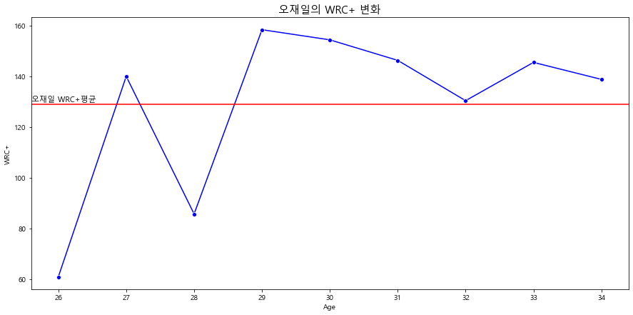

```python
plt.rcParams['figure.figsize'] = (15, 7)
plt.title('오재일의 WRC+ 변화', fontsize=15)
sns.lineplot('Age', 'WRC+', data=oh, marker='o', color='blue')
plt.axhline(y=oh['WRC+'].mean(), color='red', mew=5)
plt.text(25.6, oh['WRC+'].mean()+1,'오재일 WRC+평균', fontsize=11)
plt.show()
```

위와 같이 WRC+ 수치의 변화를 살펴보면, 오재일은 주전으로 도약한 29세 이후부터 꾸준히 자신의 평균 이상의 높은 WRC+를 기록해주고 있는 것을 확인할 수 있습니다. 다만 전체적인 추세를 보았을 때, 지속적으로 WRC+가 감소하고 있어 에이징 커브에 따른 영향을 완전히 배제하기는 어려워 보입니다. 다행히 32세 이후에 어느정도 반등에 성공한 것으로 보이나, 이 기간 동안의 기록을 살펴보면, BABIP이 0.330과 0.359로 다소 높았기 때문에 어느정도 운이 좋았다라고 생각할 필요가 있습니다. 또한 장타율과 OPS 역시 WRC+와 마찬가지로 감소하고 있기 때문에 기량 하락에 대한 위험성이 있는 계약인 것은 분명해 보입니다.

다만 오재일이 그동안 꾸준히 높은 생산성을 유지해왔고, 커리어 평균 WRC+ 역시 130 정도로 상당히 높은 편이기에 다소 기량이 떨어지더라도 향후 몇년간은 평균 이상 (100 이상)의 WRC+는 충분히 기록해 줄 것으로 생각됩니다. 현재 오재일이 부상 문제로 인해 시즌 준비가 늦어진 상황이기에 더 자세히 판단하기는 어려우나, 이미 피렐라가 중심 타선에서 좋은 활약을 펼치고 있는 만큼 오재일이 지난해와 비슷한 정도의 활약만 보여주더라도, 암흑기 동안 나타났던 처참한 득점 생산성 문제는 아주 손쉽게 해결될 것으로 보입니다.

#### - 그래서, 삼성 라이온즈는 강팀이 되었나?

지금까지 살펴본 대대적인 투자와 타선 개혁의 효과인지 삼성 라이온즈는 현재 2031일 만에 다시 리그 1위 자리에 오르며 순항 중에 있습니다.

```python
df3.groupby(df3.Team).mean().style.apply(h_max)
```

| Team | Age | WAR | TB | BABIP | AVG | OBP | SLG | OPS | WRC+ |
| --- | --- | --- | --- | --- | --- | --- | --- | --- | --- |
| KIA | 30.888889 | 0.151111 | 24.666667 | 0.298556 | 0.249889 | 0.353111 | 0.312667 | 0.665556 | 85.822222 |
| KT | 29.900000 | 0.624000 | 30.700000 | 0.367400 | 0.312800 | 0.405500 | 0.415400 | 0.820900 | 126.170000 |
| LG | 30.800000 | 0.305000 | 27.200000 | 0.265100 | 0.238000 | 0.330200 | 0.362300 | 0.692600 | 93.190000 |
| NC | 31.700000 | 0.550000 | 32.700000 | 0.282200 | 0.264100 | 0.361300 | 0.470100 | 0.831600 | 120.730000 |
| SSG | 32.700000 | 0.349000 | 27.000000 | 0.278100 | 0.247800 | 0.343300 | 0.381400 | 0.724800 | 99.430000 |
| 두산 | 30.100000 | 0.591000 | 31.500000 | 0.339600 | 0.298500 | 0.383100 | 0.421200 | 0.804200 | 128.380000 |
| 롯데 | 31.250000 | 0.523750 | 35.125000 | 0.311875 | 0.274625 | 0.374250 | 0.413750 | 0.788125 | 113.450000 |
| 삼성 | 30.444444 | 0.596667 | 34.777778 | 0.329556 | 0.285333 | 0.370778 | 0.429667 | 0.800222 | 116.022222 |
| 키움 | 29.000000 | 0.372222 | 30.333333 | 0.318000 | 0.260222 | 0.350222 | 0.370222 | 0.720556 | 97.511111 |
| 한화 | 26.090909 | 0.225455 | 24.181818 | 0.326273 | 0.245636 | 0.341091 | 0.341182 | 0.682455 | 86.727273 |

따라서 이번 시즌 타선에 대한 투자가 통계적으로도 유의미한 변화를 불러온 것이 맞는지 판단해볼 필요가 있습니다. 다시 말해, 암흑기와 타선 투자를 통해 변화된 올해 타선 간의 WRC+ 개선 여부를 확인하기 위하여 다음과 같이 가설을 설정하고 두 집단의 평균 WRC+ 변화에 대한 t검정을 수행합니다.

H0 : 올해 삼성 라이온즈 타선은 암흑기와 비교하여 변화가 없다. (올해 WRC+ = 암흑기 WRC+)  
H1 : 올해 삼성 라이온즈 타선은 암흑기와 비교하여 개선되었다. (올해 WRC+ > 암흑기 WRC+)

```python
ttest = sp.stats.ttest_ind(df2021, sam2['WRC+'])
print('< WRC+에 대한 단측(우측) t-검정 결과 >')
print('t0 :', round(ttest[0], 4), '\np-value :', round(ttest[1]/2, 4), ' < alpha :', 0.05)
```

```
< WRC+에 대한 단측(우측) t-검정 결과 >
t0 : 2.2674
p-value : 0.0131  < alpha : 0.05
```

WRC+ 개선 여부에 대한 좀 더 확실한 정보를 얻기 위해 양측검정이 아닌 우측검정을 통해 결과를 살펴보겠습니다. 검정 결과를 살펴보면, p-value가 0.0131로 유의수준 alpha보다 작게 나타난 것을 확인할 수 있습니다. 따라서 검정 결과가 통계적으로 유의하기 때문에 H0를 기각하고 H1을 채택합니다. **즉, 타선에 대한 투자 덕분에 암흑기와 비교하여 올해 삼성 라이온즈 타선은 강해졌다고 할 수 있습니다.**

- 실제로 오재일이 부상 복귀하면서 완전체 삼성 타선이 가동된 [2021년 4월 27일 경기](https://m.sports.naver.com/game/20210427NCSS02021/record)를 보면, 달라진 삼성 타선의 위력을 확인할 수 있습니다.

## 8. 결론

2010~2015년 삼성 라이온즈의 전성기 시절, 삼성은 강한 타선으로 리그를 지배한 팀이었습니다. 하지만 2016년을 기점으로 이승엽, 박석민, 채태인, 최형우 등 핵심 타자들이 은퇴와 이적으로 팀을 떠나면서 삼성은 암흑기를 맞이하게 되었고, 그 기간 동안 미진한 세대교체와 맞물리면서 타선의 불균형과 하향 평준화를 일으켰습니다. 물론 일부 선수들이 고군분투 했으나, 이들을 제외한 나머지 선수들은 득점 생산성 부재와 평균 이하의 기량을 보이면서 팀 타선에 전혀 도움이 되지 못했습니다.